# SQUASH PA analyses

Rik J. Verheijden & Anna Cabané Ballester

2023-06-26

# 1 Introduction

In this script, we assess the association between physical activity (PA), overall survival (OS) and occurence of severe immune-related adverse events (SirAEs). PA was assessed with two measures based on the Metabolic Equivalent Task (MET) value per activity:

- **MET-hours** (variable name `totmet_hpwk`) were calculated as the sum of the time per week spend on each activity multiplied by their corresponding MET value.
- Moderate-to-vigorous-intensity physical activity during sports and leisure time (**MVPA-SL**; variable name `MZvt_HWK`) was quantified as time (in hours) spent on activities with ≥3.0 MET within sports and leisure time domains.

# 2 Prepare workspace

Empty R environment

```r
rm(list = ls())
```

Install packages

```r
install.packages("dplyr")
install.packages("table1")
install.packages("gtsummary")
install.packages("ggplot2")
install.packages("ggbeeswarm")
install.packages("rms")
install.packages("survival")
install.packages("survminer")
install.packages("ggpubr")
```

Activate packages

```r
library(dplyr)
library(table1)
library(gtsummary)
library(ggplot2)
library(ggbeeswarm)
library(rms)
library(survival)
library(survminer)
library(ggpubr)
```

Define working directory and load files.

```r
wd_path <- "..."
castordate <- "..."
```

## 2.1 Load and prepare clinical data

Load the data after preprocessing to obtain physical activity variables from SQUASH questionnaire and clinical variables.

We have three data frames:

- `data_all`: data of all patients included in the UNICIT cohort since the SQUASH questionnaire was introduced.
- `data_OS`: data from all SQUASH respondents with survival data. We will use this for assessing the correlation of physical activity with survival.
- `data_tox`: data from all SQUASH respondents with at least one year follow-up. We will use this for assessing the correlation of physical activity with severe irAEs.

```r
data_OS$OS_status <- as.numeric(as.character(recode(data_OS$OS_status, "no"="0", "yes"="1")))
```

# 3 Baseline characteristics and descriptives

## 3.1 Baseline characteristics

### 3.1.1 Table 1

We use the `table1` package to make a table of patient characteristics. See the [vignette of table1](https://cran.r-project.org/web/packages/table1/vignettes/table1-examples.html) for more details.

The functions below define how data are displayed within the table.

```r
    #function to exclude missings form percentages
my.render.cat <- function(x) {
  c("", sapply(stats.default(x), function(y) with(y,
                                                  if(PCTnoNA%in%c("NaN")){sprintf("")} #if all categories within one variable of a stratum are missing, no output
                                                  else{sprintf("%d (%0.1f%%)", FREQ, PCTnoNA)} #otherwise percentages excluding missings
                                                  )))
}

  #function to show percentage of missings if applicable
my.render.missing <- function(x, ...) {
  with(stats.apply.rounding(stats.default(is.na(x), ...), ...)$Yes,
       if(PCT==100){c(missing = sprintf(""))} #if variable is missing for all subjects within this stratum, don't show missings
       else( c(missing=sprintf("%s (%s%%)", FREQ, PCT))) #otherwise, show percentages of missings
      )
}
  #function to show continuous variables as median [Q1, Q3]
my.render.cont <- function(x, name, ...) {
  with(stats.default(x),
       c("", "median [Q1-Q3]"=sprintf("%s [%s-%s]"
                                      , round_pad(MEDIAN, digits=1)
                                      , round_pad(Q1, digits=1)
                                      , round_pad(Q3, digits=1)
                                      )
         ,"mean (SD)"=sprintf("%s (%s)"
                              , round_pad(MEAN, digits=1)
                              , round_pad(SD, digits=1))
         ))
}
```

Specify data frame to use.

```r
data <- data_OS
data$B_tumor_stage_dich <- factor(ifelse(data$B_tumor_stage%in%c("III","IIIA","IIIB","IIIC","IIID"),"III",
                                  ifelse(data$B_tumor_stage%in%c("IV","IVA","IVB","IVC","IVD"), "IV",
                                  ifelse(data$B_tumor_stage%in%"other","other",
                                         NA))),
                                  levels = c("III","IV", "other"))
```

Relabel variables and add units that you want to use in your table (all formatting to let the table look nicely):

```r
label(data$B_sex) <- "sex"
label(data$B_age) <- "age"
units(data$B_age) <- "years"
label(data$B_PS) <- "ECOG performance status"
label(data$B_tumor_type.1) <- "tumour type"
label(data$B_tumor_stage_dich) <- "stage"
label(data$B_paladj) <- "treatment intent"
label(data$B_ther_cur_regrouped.1) <- "therapy"
label(data$T1_gr3_1y) <- "severe irAE within 1 year"
label(data$B_lab_LDH) <- "lactate dehydrogenase"

label(data$totmet_hpwk_tertiles) <- "MET-hours per week"
label(data$totmet_hpwk) <- "MET-hours"
units(data$totmet_hpwk) <- "hours/week"
label(data$MZvt_HWK) <- "MVPA-SL"
units(data$MZvt_HWK) <- "hours/week"
```

Make the actual table:

- `~ B_sex + B_age + ... + B_ther_cur_regrouped.1` defines the rows;
- `| totmet_hpwk_tertiles` defines the columns;
- the rest are just to change the appearance of the table.

```r
table1(~ totmet_hpwk + MZvt_HWK + B_sex + B_age + B_PS + B_tumor_type.1 + B_tumor_stage_dich + B_paladj + B_ther_cur_regrouped.1| totmet_hpwk_tertiles,
       data = data,
       overall = "Overall",
       # caption = "Table 1: baseline characteristics of combined ipilimumab",
       # footnote = "RCC: renal cell carcinoma",
       topclass = "Rtable1-zebra",
       render.categorical = my.render.cat,
       render.continuous = my.render.cont,#c(.="median [Q1, Q3]"),
       render.missing = my.render.missing,
       droplevels = TRUE)
```

[output not shown]

### 3.1.2 Baseline characteristics of respondents vs non-respondents

Specify data frame to use.

```r
data <- data_all
data$B_tumor_stage_dich <- factor(ifelse(data$B_tumor_stage%in%c("III","IIIA","IIIB","IIIC","IIID"),"III",
                                  ifelse(data$B_tumor_stage%in%c("IV","IVA","IVB","IVC","IVD"), "IV",
                                  ifelse(data$B_tumor_stage%in%"other","other",
                                         NA))),
                                  levels = c("III","IV", "other"))
```

Relabel variables and add units that you want to use in your table (all formatting to let the table look nicely):

```r
label(data$B_sex) <- "sex"
label(data$B_age) <- "age"
units(data$B_age) <- "years"
label(data$B_PS) <- "ECOG performance status"
label(data$B_tumor_type.1) <- "tumour type"
label(data$B_tumor_stage_dich) <- "stage"
label(data$B_paladj) <- "treatment intent"
label(data$B_ther_cur_regrouped.1) <- "therapy"
label(data$T1_gr3_1y) <- "severe irAE within 1 year"
label(data$B_lab_LDH) <- "lactate dehydrogenase"

label(data$Q_squash_respondent) <- "SQUASH respondent"
```

Make the actual table comparing SQUASH respondents to non-respondents.

```r
table1(~ B_sex + B_age + B_PS + B_tumor_type.1 + B_tumor_stage_dich + B_paladj + B_ther_cur_regrouped.1| Q_squash_respondent,
       data = data,
       overall = FALSE,
       # caption = "Table 1: baseline characteristics of combined ipilimumab",
       # footnote = "RCC: renal cell carcinoma",
       topclass = "Rtable1-zebra",
       render.categorical = my.render.cat,
       render.continuous = my.render.cont,#c(.="median [Q1, Q3]"),
       render.missing = my.render.missing,
       droplevels = TRUE)
```

|  | no (N=47) | yes (N=251) |
| --- | --- | --- |
| sex |  |  |
| male | 29 (61.7%) | 167 (66.5%) |
| female | 18 (38.3%) | 84 (33.5%) |
| age (years) |  |  |
| median [Q1-Q3] | 67.0 [60.0-72.0] | 64.0 [55.0-73.0] |
| mean (SD) | 64.4 (12.8) | 62.9 (12.4) |
| ECOG performance status |  |  |
| 0 | 19 (40.4%) | 126 (50.2%) |
| 1 | 17 (36.2%) | 101 (40.2%) |
| 2 | 8 (17.0%) | 16 (6.4%) |
| 3 | 1 (2.1%) | 2 (0.8%) |
| 4 | 0 (0.0%) | 0 (0.0%) |
| unknown | 2 (4.3%) | 6 (2.4%) |
| tumour type |  |  |
| melanoma | 21 (44.7%) | 153 (61.0%) |
| NSCLC | 14 (29.8%) | 38 (15.1%) |
| RCC | 3 (6.4%) | 28 (11.2%) |
| other | 9 (19.1%) | 32 (12.7%) |
| stage |  |  |
| III | 16 (34.0%) | 104 (41.4%) |
| IV | 31 (66.0%) | 144 (57.4%) |
| other | 0 (0.0%) | 3 (1.2%) |
| treatment intent |  |  |
| palliative | 34 (72.3%) | 150 (59.8%) |
| adjuvant | 13 (27.7%) | 101 (40.2%) |
| therapy |  |  |
| anti-PD-(L)1 | 31 (67.4%) | 165 (65.7%) |
| cICI | 10 (21.7%) | 61 (24.3%) |
| ICI + chemo/targeted therapy | 5 (10.9%) | 25 (10.0%) |
| missing | 1 (2.1%) | 0 (0%) |

### 3.1.3 Other baseline characteristics

Overall descriptives for age, MET-hours and MVPA-SL.

```r
summary(data$B_age)
```

```
##    Min. 1st Qu.  Median    Mean 3rd Qu.    Max.
##    20.0    56.0    65.0    63.1    72.0    94.0
```

```r
summary(data$totmet_hpwk)
```

```
##    Min. 1st Qu.  Median    Mean 3rd Qu.    Max.    NA's
##    0.00   39.82   75.35   83.39  112.56  370.60      46
```

```r
summary(data$MZvt_HWK)
```

```
##    Min. 1st Qu.  Median    Mean 3rd Qu.    Max.    NA's
##   0.000   0.875   4.000   5.810   8.500  38.500      47
```

## 3.2 Overall follow-up time and overall survival

Date of first treatment start.

```r
min(data$C1_date)
```

```
## [1] "2019-10-16"
```

```r
max(data$C1_date)
```

```
## [1] "2022-10-18"
```

```r
max(data$OS_date)
```

```
## [1] "2023-01-31"
```

We will use the reverse Kaplan Meier method to estimate the median follow-up time, where we censor for death and conversely use the last follow-up time point as event.

```r
data$KMrev <- as.numeric(ifelse(data$OS_status%in%1,0,1))
survfit(Surv(OS_days, KMrev) ~ 1 , data = data)
```

```
## Call: survfit(formula = Surv(OS_days, KMrev) ~ 1, data = data)
##
##        n events median 0.95LCL 0.95UCL
## [1,] 298    298    440     409     488
```

We obtain the predicted median follow-up time in days.

```r
survfit(Surv(OS_days, OS_status) ~ 1 , data = data)
```

```
## Call: survfit(formula = Surv(OS_days, OS_status) ~ 1, data = data)
##
##        n nevent   rmean*
## (s0) 298      0 839.5851
## yes  298     91 336.4149
##    *restricted mean time in state (max time = 1176 )
```

## 3.3 PA descriptives

### 3.3.1 Correlation of MET-hours and MVPA-SL

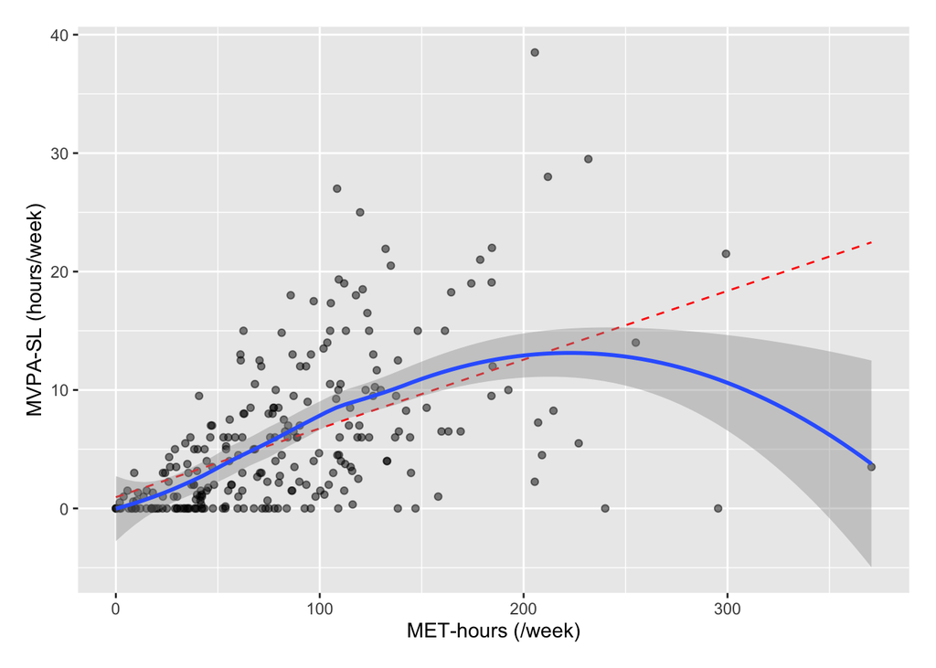

```r
ggplot(data=data, aes(x=totmet_hpwk, y=MZvt_HWK)
       )+ geom_point(alpha=.5
       )+ geom_smooth(method=lm, se=F
                     ,color="red", linetype="dashed", linewidth=.5
       )+ geom_smooth(method= loess
       # )+ geom_text(data=data[data$totmet_hpwk>200|data$MZvt_HWK>20,], aes(x=totmet_hpwk, y=MZvt_HWK, label=record_id)
       #              ,hjust=1,vjust=-.1
       # )+coord_cartesian(xlim=c(0,200), ylim = c(0,20)
       )+ labs(x="MET-hours (/week)", y="MVPA-SL (hours/week)"
       )+theme(plot.margin =  margin(1,1,1,1,unit = "lines")
       )
```

### 3.3.2 PA according to ECOG performance status.

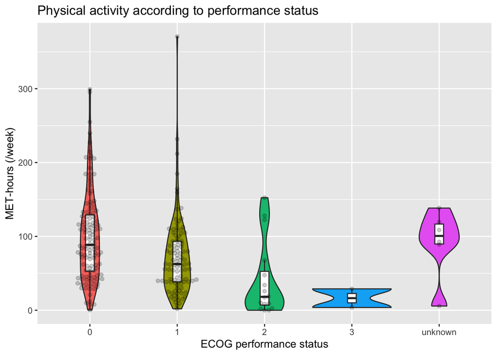

```r
ggplot(data=data_OS, aes(x=B_PS, y=totmet_hpwk)
       )+ geom_violin(aes(fill=B_PS), alpha=1
       )+ geom_boxplot(alpha=1, width=.1, outlier.shape = NA
       )+ geom_beeswarm(alpha=.2
       )+ labs(title="Physical activity according to performance status",x="ECOG performance status", y="MET-hours (/week)"
       )+ theme(legend.position="none"
       )
```

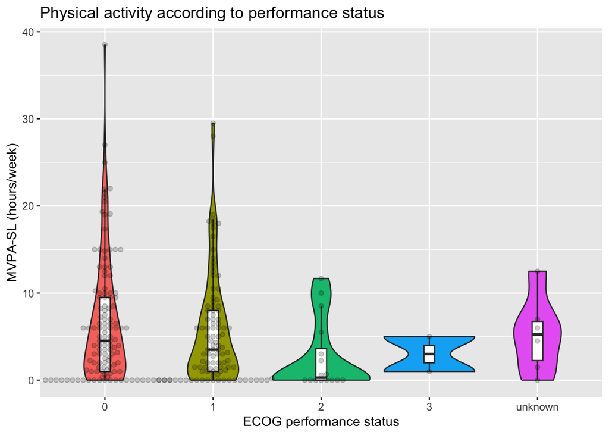

```r
ggplot(data=data_OS, aes(x=B_PS, y=MZvt_HWK)
       )+ geom_violin(aes(fill=B_PS), alpha=1
       )+ geom_boxplot(alpha=1, width=.1, outlier.shape = NA
       )+ geom_beeswarm(alpha=.2
       )+ labs(title="Physical activity according to performance status",x="ECOG performance status", y="MVPA-SL (hours/week)"
       )+ theme(legend.position="none"
       )
```

Make variable with ECOG PS 0, 1 or >1. We will use this variable in sensitivity analyses.

```r
data_OS$B_PS_tri <- factor(ifelse(data_OS$B_PS%in%"0","0",
                           ifelse(data_OS$B_PS%in%"1","1",
                                  ifelse(data_OS$B_PS%in%c("2","3","4"),"2-3",
                                         NA))))
table(data_OS$B_PS_tri, data_OS$B_PS, useNA="always")
```

```
##
##          0   1   2   3   4 unknown <NA>
##   0    126   0   0   0   0       0    0
##   1      0 101   0   0   0       0    0
##   2-3    0   0  16   2   0       0    0
##   <NA>   0   0   0   0   0       6    0
```

```r
data_tox$B_PS_tri <- factor(ifelse(data_tox$B_PS%in%"0","0",
                           ifelse(data_tox$B_PS%in%"1","1",
                                  ifelse(data_tox$B_PS%in%c("2","3","4"),"2-3",
                                         NA))))
table(data_tox$B_PS_tri, data_tox$B_PS, useNA="always")
```

```
##
##          0   1   2   3   4 unknown <NA>
##   0    103   0   0   0   0       0    0
##   1      0  86   0   0   0       0    0
##   2-3    0   0  13   1   0       0    0
##   <NA>   0   0   0   0   0       6    0
```

# 4 Severe irAEs

We will now assess the correlation of physical activity with severe immune-related adverse events (>=grade 3 irAEs). Notably, death is a competing risk here (e.g. people can die before they have had time to develop irAEs). We discussed using logistic regression, ‘regular’ Cox regression, a Fine and Gray model (=subdistribution hazard model) or a cause-specific hazard model. All of these have their shortcomings. We decided to use a logistic regression model in patients with at least one year of follow-up (started one year before data cut-off, so before *February 2nd 2022*) with occurence of a grade 3 or higher irAE within one year.

Notably, only one patient in our cohort developed his/her first severe irAE after one year. This patient is thus regarded as without severe irAE <1 year.

```r
table(data_tox$T1_gr3_1y, useNA = "always")
```

```
##
##   no  yes <NA>
##  171   38    0
```

```r
data_tox[data_tox$T1_gr3_calc_present%in%"yes"&data_tox$T1_gr3_1y%in%"no",c("B_ther_cur_start","T1_gr3_date", "T1_gr3_days")]
```

```
##     B_ther_cur_start T1_gr3_date T1_gr3_days
## 255       2020-08-13  2021-12-16         490
```

## 4.1 MET-hours and severe irAEs

To give some feeling, we calculate the proportion of patients with severe irAEs among each tertile of total PA.

```r
tbl_summary(data_tox[, c("totmet_hpwk_tertiles", "T1_gr3_1y")]
            , by="totmet_hpwk_tertiles"
            , missing= "always"
            , percent = "column")
```

| **Characteristic** | **[0,51]**, N = 73<sup>1</sup> | **(51,101]**, N = 69<sup>1</sup> | **(101,371]**, N = 67<sup>1</sup> |
| --- | --- | --- | --- |
| T1_gr3_1y | 21 (29%) | 10 (14%) | 7 (10%) |
| Unknown | 0 | 0 | 0 |

<sup>1</sup> n (%)

### 4.1.1 SirAEs~MET-hours logistic regression - tertiles

Adjusted logistic regression for tertiles variable.

```r
glm_tert.adj <- glm(formula = T1_gr3_1y ~ totmet_hpwk_tertiles + B_sex + B_age + B_tumor_type.1 + B_paladj + B_ther_cur_regrouped.1, family = binomial(link = "logit"), data = data_tox)
glm_tert.adj_PS <- glm(formula = T1_gr3_1y ~ totmet_hpwk_tertiles + B_sex + B_age + B_tumor_type.1 + B_paladj + B_ther_cur_regrouped.1 + B_PS_tri, family = binomial(link = "logit"), data = data_tox)
tbl_merge(list(
  tbl_regression(glm_tert.adj, exponentiate=T),
  tbl_regression(glm_tert.adj_PS, exponentiate=T)
  ),
  tab_spanner = c("without ECOG PS", "with ECOG PS")
)
```

| **Characteristic** | without ECOG PS **OR**<sup>1</sup> | without ECOG PS **95% CI**<sup>1</sup> | without ECOG PS **p-value** | with ECOG PS **OR**<sup>1</sup> | with ECOG PS **95% CI**<sup>1</sup> | with ECOG PS **p-value** |
| --- | --- | --- | --- | --- | --- | --- |
| totmet_hpwk_tertiles |  |  |  |  |  |  |
| [0,51] | — | — |  | — | — |  |
| (51,101] | 0.35 | 0.12, 0.90 | 0.035 | 0.32 | 0.11, 0.89 | 0.034 |
| (101,371] | 0.19 | 0.06, 0.56 | 0.004 | 0.21 | 0.06, 0.62 | 0.007 |
| B_sex |  |  |  |  |  |  |
| male | — | — |  | — | — |  |
| female | 1.45 | 0.60, 3.47 | 0.4 | 1.62 | 0.65, 4.01 | 0.3 |
| B_age | 1.04 | 1.01, 1.08 | 0.027 | 1.04 | 1.00, 1.09 | 0.041 |
| B_tumor_type.1 |  |  |  |  |  |  |
| melanoma | — | — |  | — | — |  |
| NSCLC | 0.62 | 0.10, 2.95 | 0.6 | 0.74 | 0.11, 3.58 | 0.7 |
| RCC | 0.36 | 0.10, 1.27 | 0.12 | 0.35 | 0.09, 1.27 | 0.12 |
| other | 0.53 | 0.09, 2.52 | 0.4 | 0.67 | 0.11, 3.45 | 0.6 |
| B_paladj |  |  |  |  |  |  |
| palliative | — | — |  | — | — |  |
| adjuvant | 0.76 | 0.20, 2.98 | 0.7 | 1.02 | 0.24, 4.63 | >0.9 |
| B_ther_cur_regrouped.1 |  |  |  |  |  |  |
| anti-PD-(L)1 | — | — |  | — | — |  |
| cICI | 14.3 | 3.67, 64.8 | <0.001 | 18.4 | 4.40, 93.2 | <0.001 |
| ICI + chemo/targeted therapy | 1.75 | 0.26, 11.1 | 0.5 | 1.92 | 0.27, 12.7 | 0.5 |
| B_PS_tri |  |  |  |  |  |  |
| 0 |  |  |  | — | — |  |
| 1 |  |  |  | 0.96 | 0.35, 2.60 | >0.9 |
| 2-3 |  |  |  | 1.09 | 0.17, 6.18 | >0.9 |

<sup>1</sup> OR = Odds Ratio, CI = Confidence Interval

### 4.1.2 SirAEs~MET-hours logistic regression - continuous linear

Adjusted logistic regression for continuous linear variable.

```r
glm_lin.adj <- glm(formula = T1_gr3_1y ~ totmet_hpwk + B_sex + B_age + B_tumor_type.1 + B_paladj + B_ther_cur_regrouped.1, family = binomial(link = "logit"), data = data_tox)
# tbl_regression(glm_lin.adj, exponentiate=T)
```

### 4.1.3 SirAEs~MET-hours logistic regression - assumptions

Check assumptions:

- Observations are independent:
  - is the case by design.
- Relationships of explanatory variables with outcome should be linear:
  - Residual vs Fitted(=predictor) plot per (numeric) covariate.
  - Should show a horizontal band without curvature/pattern.
  - Since our outcome is binary, we need to bin the residuals.
- Residuals should be normally distributed:
  - QQ-plot: points should lie on one diagonal line.
- Homoscedasticity=homogeneity of variances:
  - The spread of the residuals does not depend on the linear predictor.
  - Residual vs Fitted(=linear predictor) plot.
  - Should show a horizontal band without curvature/pattern.

Make function to make binned Residual vs Fitted plot.

```r
residual_lp_binned <- function(data,
                               fit,
                               title = expression(paste("Binned dev. residuals against ",hat(eta))),
                               n_breaks = max(c(10, min(c(floor(nrow(data)/10), 50))))
                               ){
  if(!is.null(fit$na.action)){
    data <- data[-c(fit$na.action),]
  }
  data <- dplyr::mutate(data, residuals=residuals(fit, type = "pearson"),linpred=predict(fit, type = "link"))
  gdf <- dplyr::group_by(data, cut(linpred, breaks=unique(quantile(linpred, (1:(n_breaks))/(n_breaks+1)))))
  diagdf <- dplyr::summarise(gdf, residuals=mean(residuals),linpred=mean(linpred))
  data$residuals <- data$linpred <- NULL
  ggplot2::ggplot(diagdf, aes(y=residuals, x=linpred)
                  )+ ggplot2::geom_hline(yintercept = 0
                                         ,color = "darkgrey"
                  )+ ggplot2::geom_point(
                  )+ ggplot2::labs(x=expression(hat(eta))
                                   ,y="pearson residuals (binned)"
                                   ,title=title
                                   ,caption = deparse1(fit$formula)
                  )+ ggplot2::theme_bw(
                  )
}
```

Assess linearity of `totmet_hpwk` and `B_age` with outcome.

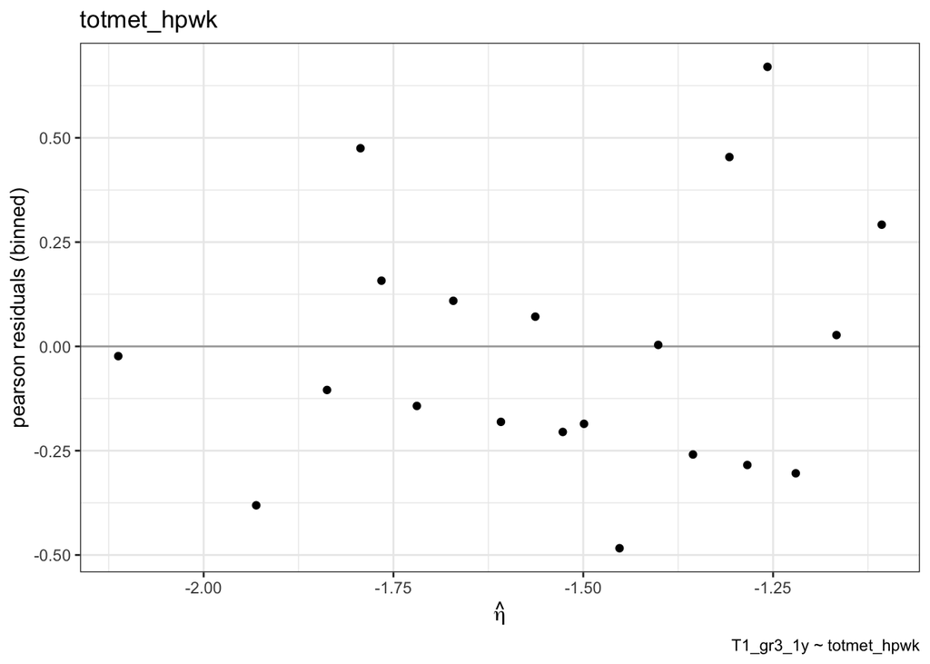

```r
fit <- glm(formula = T1_gr3_1y ~ totmet_hpwk , family = binomial(link = "logit"), data = data_tox)
residual_lp_binned(data_tox, fit = fit, title = "totmet_hpwk")
```

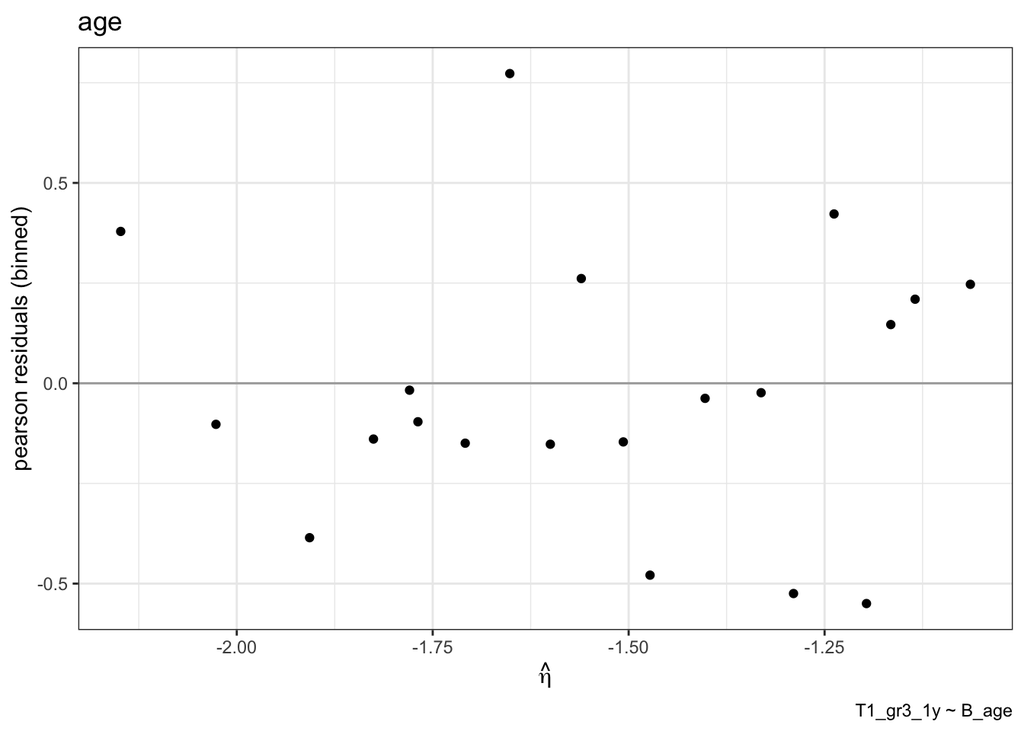

```r
fit <- glm(formula = T1_gr3_1y ~ B_age , family = binomial(link = "logit"), data = data_tox)
residual_lp_binned(data_tox, fit = fit, title = "age")
```

Assess whether residuals are normally distributed.

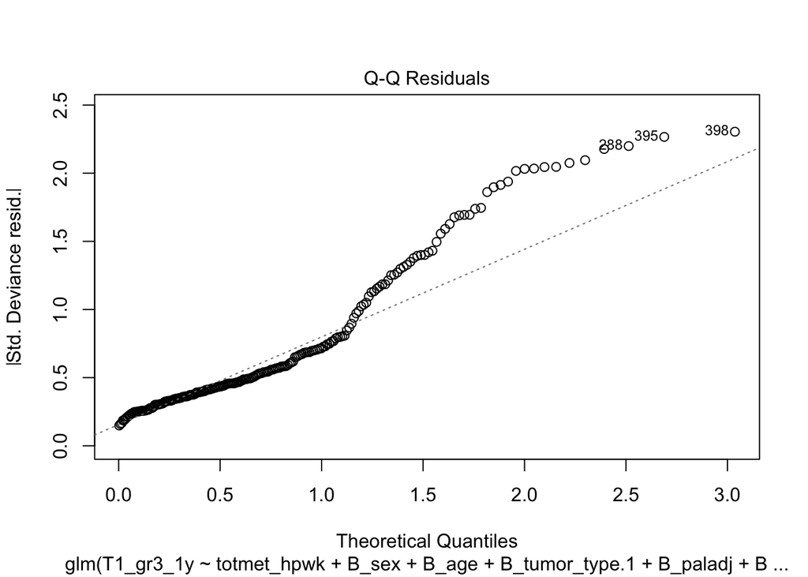

```r
plot(glm_lin.adj, which = 2)
```

Check homoscedasticity.

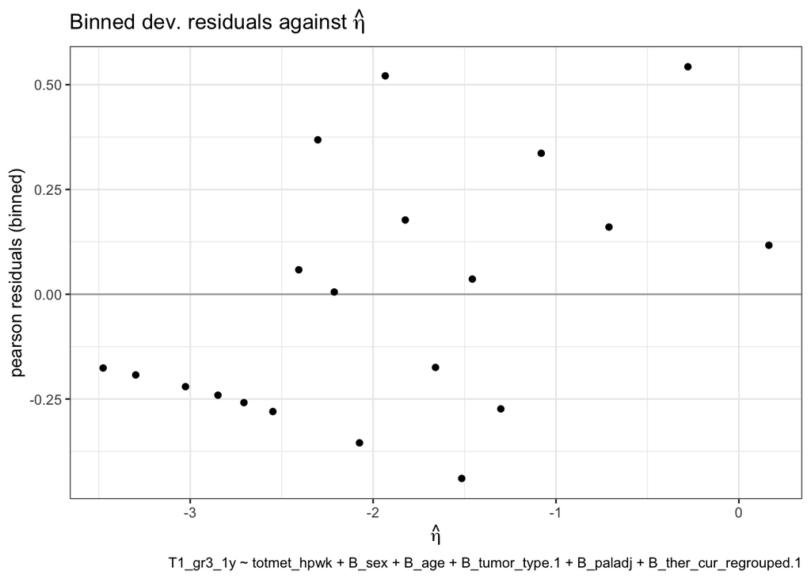

```r
residual_lp_binned(data_tox, glm_lin.adj)
```

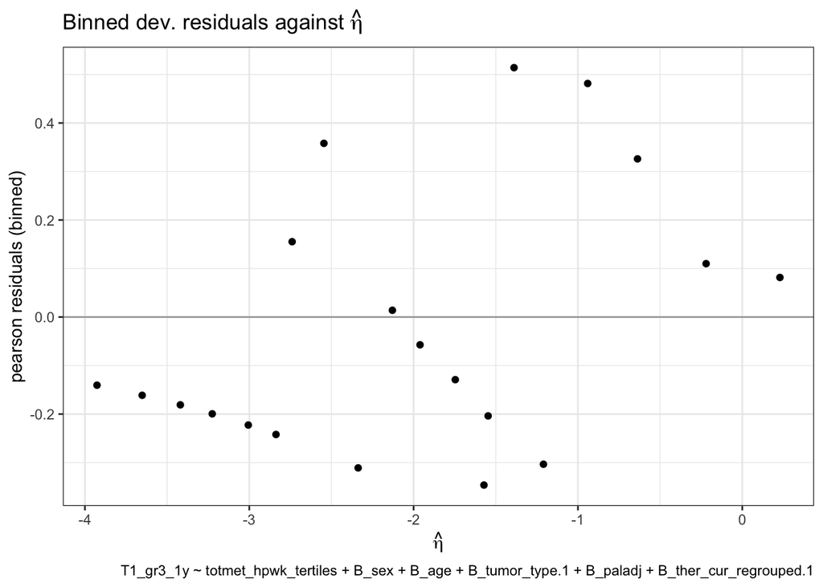

```r
residual_lp_binned(data_tox, glm_tert.adj)
```

### 4.1.4 SirAEs~MET-hours logistic regression - continuous splines

#### 4.1.4.1 Knot specification

Restricted cubic splines work with a certain number of knots: a hinge point for the distribution which gets smoothed out by a cubic parameter. We can specify the number and locations of knots or we can choose to let the knot locations be chosen by our software. Usually, 3 to 5 knots suffices. Consider that each knot ‘costs’ us a degree of freedom and that too many knots may likely result in overfitting. Therefore, we will use 3 knots here.

**We will use the same knots as in the OS analysis.**

We make use of the `rcspline.eval()` function in the `Hmisc` package.

```r
k.pos.totmet_hpwk <- rcspline.eval(data_OS$totmet_hpwk #variable to use splines for
                            , nk=3 #number of knots
                            , inclx=FALSE
                            , knots.only=T #only store knots
                            , type="ordinary"
                            , norm=2
                            , rpm=NULL
                            , pc=FALSE
                            , fractied=0.05)
```

#### 4.1.4.2 Initial regression

Conduct survival analysis using splines regression by the prespecified knots. We make use of the `rcs()` function in package `rms` which provides restricted cubic splines.

```r
glm_rcs.adj <- glm(formula = T1_gr3_1y ~ rms::rcs(totmet_hpwk, k.pos.totmet_hpwk) + B_sex + B_age + B_tumor_type.1 + B_paladj + B_ther_cur_regrouped.1, family = binomial(link = "logit"), data = data_tox)
tbl_regression(glm_rcs.adj, exponentiate=T)
```

| **Characteristic** | **OR**<sup>1</sup> | **95% CI**<sup>1</sup> | **p-value** |
| --- | --- | --- | --- |
| totmet_hpwk |  |  |  |
| rms::rcs(totmet_hpwk, k.pos.totmet_hpwk)totmet_hpwk | 0.97 | 0.95, 0.99 | 0.004 |
| rms::rcs(totmet_hpwk, k.pos.totmet_hpwk)totmet_hpwk' | 1.03 | 1.01, 1.05 | 0.018 |
| B_sex |  |  |  |
| male | — | — |  |
| female | 1.52 | 0.63, 3.63 | 0.3 |
| B_age | 1.04 | 1.00, 1.08 | 0.040 |
| B_tumor_type.1 |  |  |  |
| melanoma | — | — |  |
| NSCLC | 0.62 | 0.10, 2.91 | 0.6 |
| RCC | 0.36 | 0.09, 1.24 | 0.11 |
| other | 0.51 | 0.09, 2.43 | 0.4 |
| B_paladj |  |  |  |
| palliative | — | — |  |
| adjuvant | 0.71 | 0.18, 2.78 | 0.6 |
| B_ther_cur_regrouped.1 |  |  |  |
| anti-PD-(L)1 | — | — |  |
| cICI | 11.8 | 3.09, 52.0 | <0.001 |
| ICI + chemo/targeted therapy | 1.68 | 0.26, 10.2 | 0.6 |

<sup>1</sup> OR = Odds Ratio, CI = Confidence Interval

##### 4.1.4.2.1 Check added value of using splines

We can check whether using restricted cubic splines improves the model fit (statistically). A p-value <0.05 indicates that the model fit is statistically different.

We can check whether `totmet_hpwk` improves the model fit at all (compare a model with splines for `totmet_hpwk` (*Model 1*) to a model without `totmet_hpwk` (*Model 2*)).

```r
anova(glm_rcs.adj,update(glm_rcs.adj,.~.-rms::rcs(totmet_hpwk, k.pos.totmet_hpwk)), test = "Chisq")
```

```
## Analysis of Deviance Table
##
## Model 1: T1_gr3_1y ~ rms::rcs(totmet_hpwk, k.pos.totmet_hpwk) + B_sex +
##     B_age + B_tumor_type.1 + B_paladj + B_ther_cur_regrouped.1
## Model 2: T1_gr3_1y ~ B_sex + B_age + B_tumor_type.1 + B_paladj + B_ther_cur_regrouped.1
##   Resid. Df Resid. Dev Df Deviance Pr(>Chi)
## 1       198     151.43
## 2       200     160.70 -2  -9.2677 0.009717 **
## ---
## Signif. codes:  0 '***' 0.001 '**' 0.01 '*' 0.05 '.' 0.1 ' ' 1
```

Than, we check whether using splines for `totmet_hpwk` gives a better fit than adding it as a linear variable (compare a model with splines for `totmet_hpwk` (*Model 1*) to a model with `totmet_hpwk` as is (*Model 2*)).

```r
anova(glm_rcs.adj,update(glm_rcs.adj,.~.-rms::rcs(totmet_hpwk, k.pos.totmet_hpwk)+totmet_hpwk), test = "Chisq")
```

```
## Analysis of Deviance Table
##
## Model 1: T1_gr3_1y ~ rms::rcs(totmet_hpwk, k.pos.totmet_hpwk) + B_sex +
##     B_age + B_tumor_type.1 + B_paladj + B_ther_cur_regrouped.1
## Model 2: T1_gr3_1y ~ B_sex + B_age + B_tumor_type.1 + B_paladj + B_ther_cur_regrouped.1 +
##     totmet_hpwk
##   Resid. Df Resid. Dev Df Deviance Pr(>Chi)
## 1       198     151.43
## 2       199     157.38 -1  -5.9535  0.01469 *
## ---
## Signif. codes:  0 '***' 0.001 '**' 0.01 '*' 0.05 '.' 0.1 ' ' 1
```

#### 4.1.4.3 Visualise the regression coefficient

We want to visualise the Odds ratio (OR) for developing a severe irAE within 1 year over the trajectory of our variable of interest (`totmet_hpwk`). To do this, we will make a dummy dataset to predict the OR for certain values of `totmet_hpwk`. We will also obtain the 95% confidence interval (CI).

##### 4.1.4.3.1 Make dummy dataset to obtain predicted OR

```r
if(!is.null(glm_rcs.adj$na.action)){
  newdf <- data_tox[-c(glm_rcs.adj$na.action),]
} else {
  newdf <- data_tox
}

newdf$totmet_hpwk <- c(seq(min(data_tox$totmet_hpwk),max(data_tox$totmet_hpwk),length=(nrow(newdf)-length(k.pos.totmet_hpwk))), k.pos.totmet_hpwk)
```

Now we make a model matrix, which is needed in the subsequent steps.

```r
mm <- model.matrix(glm_rcs.adj, data=newdf)
mm[,!colnames(mm) %in% colnames(mm)[grep("totmet_hpwk",colnames(mm))]] <- 0 # set all variables not about totmet_hpwk to 0
```

For each value of our sequence of `totmet_hpwk`, we obtain its predicted coefficient (=`eta`) and predicted standard error (=`pse`). With these, we compute the predicted 95% conficence intervalls (`plo` and `phi` for lower and upper CI). We store these in a data frame called `est`.

```r
est <- data.frame(totmet_hpwk=newdf$totmet_hpwk,eta=mm%*%coef(glm_rcs.adj)) #predicted coefficient
pvar <- diag(mm %*% tcrossprod(vcov(glm_rcs.adj),mm)) #predicted variance
est <- data.frame(est,pse=sqrt(pvar)) #predicted standard error
est <- with(est,
            data.frame(est,
                       plo=eta-qnorm(0.975)*pse, #predicted lower 95%CI bound
                       phi=eta+qnorm(0.975)*pse)) #predicted upper 95%CI bound
```

For Cox regression and logistic regression we need to exponentiate the coefficient and confidence bounds to obtain OR and 95% CI.

```r
est[,c("eta","plo","phi")] <- exp(est[,c("eta","plo","phi")])
```

We remove duplicates (e.g. if we have two of the same values for `totmet_hpwk`) and sort on `totmet_hpwk`.

```r
est <- est[!duplicated(est),] #remove duplicates
est <- est[order(est$totmet_hpwk),] #sort based on var1 order
```

##### 4.1.4.3.2 Make splines plot

Now, we can finally make the actual plot.

- We use `geom_ribbon()` to obtain the 95%CI.
- We use `geom_hline()` to draw a line at the reference value 1.
- We use `geom_line()` to draw the line for the HR.
- We use `geom_point()` to draw the location of the splines.
- We use `geom_rug()` to visualise the instances of `var1` on the x-axis.
- We use `scale_y_log10()` to transform the y-axis by a 10 base logarithm and specify the breaks.

```r
p_splines_tox.OR_MET <- ggplot(data = est
                )+ geom_ribbon(aes(x=totmet_hpwk, ymin = plo, ymax = phi) #color 95%CI
                               , colour = rgb(248,136,44,maxColorValue = 255,alpha=100)
                               , fill=rgb(252,211,178,maxColorValue = 255,alpha=100)
                               , alpha=0.4
                )+ geom_hline(yintercept=1 #add horizontal line at 1
                              , color="dark grey"
                              , linetype="dashed"
                              , size=1
                )+ geom_line(aes(x=totmet_hpwk,y=eta) #add estimated HR
                             , color = "coral3"
                             , size = 1
                )+ geom_point(data=est[est$totmet_hpwk%in%k.pos.totmet_hpwk,] #to plot the places of the knots
                , aes(x=totmet_hpwk, y=eta)
                )+ geom_rug(data = data_tox, aes(x=totmet_hpwk) #add rugs representing real observations for totmet_hpwk
                            , sides = "b"
                            , length = grid::unit(0.02, "npc")
                            , color = "grey"
                            , alpha = .3
                )+ scale_x_continuous(expand = c(0, 0) #set axes directly at 0
                )+ scale_y_log10(breaks = unique(c(0.01,seq(0,1,.2)/10,seq(0,1,.2), seq(0,1,.2)*10))
                # )+ annotation_logticks(base = 10, sides = "l", outside=F , scaled = T, color = "black",alpha = .5
                )+ coord_cartesian(#xlim = c(0, 201) #set x-axis
                                   ylim = c(0.01,10) #set y-axis
                # )+ ggtitle("" #add title
                )+ xlab("MET-hours (/week)" #add x-axis label
                )+ ylab("Odds ratio for severe irAE" #add y-axis label
                )+ theme_light( #add/alter theme
                )+ theme(plot.margin = margin(0.5,3,0.5,0.5, unit = "char")
                )
p_splines_tox.OR_MET
```

[output not shown]

### 4.1.5 Visualize predicted probabilities of ficticious patient

Alternatively, we can visualize the predicted probabilities given a patient in whom only the variable of interest changes.

```r
newdf <- with(data_tox,
              expand.grid(totmet_hpwk=c(seq(min(totmet_hpwk),max(totmet_hpwk),length=300), k.pos.totmet_hpwk)
                          , B_sex = levels(B_sex)[1] #reference level for sex
                          , B_age = round(median(B_age), digits = 0)
                          , B_tumor_type.1 = levels(B_tumor_type.1)[1]
                          , B_paladj = levels(B_paladj)[1]
                          , B_ther_cur_regrouped.1 = levels(B_ther_cur_regrouped.1)[1]
                          , B_PS_tri = levels(B_PS_tri)[1]
                          ))
```

```r
newdf$prob <- predict(glm_rcs.adj, newdata = newdf, type = "response")
```

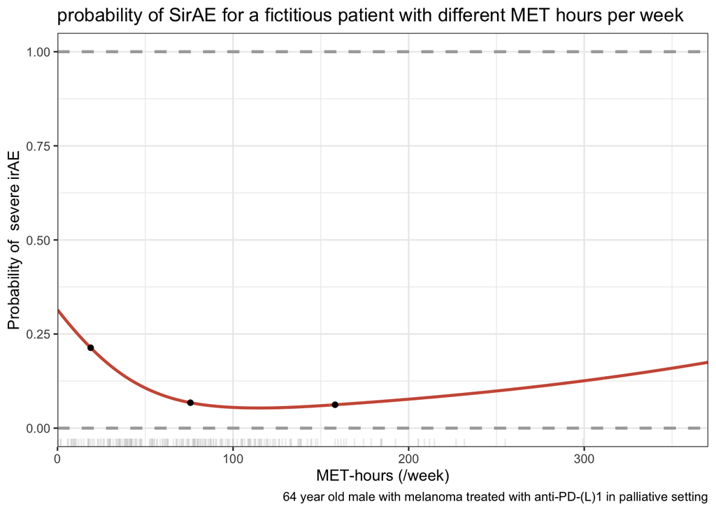

```r
p_splines_tox.prob <- ggplot(data = newdf
                )+ geom_hline(yintercept=1 #add horizontal line at 1
                              , color="dark grey"
                              , linetype="dashed"
                              , size=1
                )+ geom_hline(yintercept=0 #add horizontal line at 0
                              , color="dark grey"
                              , linetype="dashed"
                              , size=1
                )+ geom_line(aes(x=totmet_hpwk,y=prob) #add estimated HR
                             , color = "coral3"
                             , size = 1
                )+ geom_point(data=newdf[newdf$totmet_hpwk%in%k.pos.totmet_hpwk,] #to plot the places of the knots
                , aes(x=totmet_hpwk, y=prob)
                )+ geom_rug(data = data_tox, aes(x=totmet_hpwk) #add rugs representing real observations for totmet_hpwk
                            , sides = "b"
                            , length = grid::unit(0.02, "npc")
                            , color = "grey"
                            , alpha = .3
                )+ scale_x_continuous(expand = c(0, 0) #set axes directly at 0
                )+ coord_cartesian(#xlim = c(0, 201) #set x-axis
                                   ylim = c(0.0,1.0) #set y-axis
                )+ labs(x = "MET-hours (/week)" #add x-axis label
                        ,y ="Probability of  severe irAE" #add y-axis label
                        ,title = "probability of SirAE for a fictitious patient with different MET hours per week"
                        ,caption = "64 year old male with melanoma treated with anti-PD-(L)1 in palliative setting"
                )+ theme_bw( #add/alter theme
                )

p_splines_tox.prob
```

## 4.2 MVPA-SL and severe irAEs

To give some feeling, we calculate the proportion of patients with severe irAEs among each tertile of MVPA-SL.

```r
tbl_summary(data_tox[, c("MZvt_HWK_tertiles", "T1_gr3_1y")]
            , by="MZvt_HWK_tertiles"
            , missing= "always"
            , percent = "column")
```

| **Characteristic** | **[0,1.5]**, N = 74<sup>1</sup> | **(1.5,6.5]**, N = 70<sup>1</sup> | **(6.5,38.5]**, N = 65<sup>1</sup> |
| --- | --- | --- | --- |
| T1_gr3_1y | 22 (30%) | 11 (16%) | 5 (7.7%) |
| Unknown | 0 | 0 | 0 |

<sup>1</sup> n (%)

### 4.2.1 SirAEs~MVPA-SL logistic regression - tertiles

Adjusted logistic regression for tertiles variable.

```r
glm_tert.adj <- glm(formula = T1_gr3_1y ~ MZvt_HWK_tertiles + B_sex + B_age + B_tumor_type.1 + B_paladj + B_ther_cur_regrouped.1, family = binomial(link = "logit"), data = data_tox)
glm_tert.adj_PS <- glm(formula = T1_gr3_1y ~ MZvt_HWK_tertiles + B_sex + B_age + B_tumor_type.1 + B_paladj + B_ther_cur_regrouped.1 + B_PS_tri, family = binomial(link = "logit"), data = data_tox)
tbl_merge(list(
  tbl_regression(glm_tert.adj, exponentiate=T),
  tbl_regression(glm_tert.adj_PS, exponentiate=T)
  ),
  tab_spanner = c("without ECOG PS", "with ECOG PS")
)
```

| **Characteristic** | without ECOG PS **OR**<sup>1</sup> | without ECOG PS **95% CI**<sup>1</sup> | without ECOG PS **p-value** | with ECOG PS **OR**<sup>1</sup> | with ECOG PS **95% CI**<sup>1</sup> | with ECOG PS **p-value** |
| --- | --- | --- | --- | --- | --- | --- |
| MZvt_HWK_tertiles |  |  |  |  |  |  |
| [0,1.5] | — | — |  | — | — |  |
| (1.5,6.5] | 0.41 | 0.15, 1.03 | 0.062 | 0.39 | 0.14, 1.00 | 0.055 |
| (6.5,38.5] | 0.11 | 0.03, 0.36 | <0.001 | 0.12 | 0.03, 0.40 | 0.001 |
| B_sex |  |  |  |  |  |  |
| male | — | — |  | — | — |  |
| female | 1.10 | 0.45, 2.68 | 0.8 | 1.28 | 0.51, 3.22 | 0.6 |
| B_age | 1.06 | 1.02, 1.10 | 0.003 | 1.06 | 1.02, 1.11 | 0.007 |
| B_tumor_type.1 |  |  |  |  |  |  |
| melanoma | — | — |  | — | — |  |
| NSCLC | 0.60 | 0.08, 3.16 | 0.6 | 0.72 | 0.10, 3.89 | 0.7 |
| RCC | 0.30 | 0.08, 1.10 | 0.078 | 0.28 | 0.07, 1.08 | 0.072 |
| other | 0.53 | 0.09, 2.61 | 0.4 | 0.68 | 0.11, 3.63 | 0.7 |
| B_paladj |  |  |  |  |  |  |
| palliative | — | — |  | — | — |  |
| adjuvant | 0.85 | 0.21, 3.51 | 0.8 | 1.20 | 0.26, 5.98 | 0.8 |
| B_ther_cur_regrouped.1 |  |  |  |  |  |  |
| anti-PD-(L)1 | — | — |  | — | — |  |
| cICI | 15.1 | 3.75, 73.3 | <0.001 | 20.0 | 4.55, 110 | <0.001 |
| ICI + chemo/targeted therapy | 1.97 | 0.28, 13.8 | 0.5 | 2.22 | 0.29, 16.0 | 0.4 |
| B_PS_tri |  |  |  |  |  |  |
| 0 |  |  |  | — | — |  |
| 1 |  |  |  | 0.96 | 0.35, 2.62 | >0.9 |
| 2-3 |  |  |  | 1.24 | 0.20, 6.98 | 0.8 |

<sup>1</sup> OR = Odds Ratio, CI = Confidence Interval

### 4.2.2 SirAEs~MVPA-SL logistic regression - continuous linear

Adjusted logistic regression for continuous linear variable.

```r
glm_lin.adj <- glm(formula = T1_gr3_1y ~ MZvt_HWK + B_sex + B_age + B_tumor_type.1 + B_paladj + B_ther_cur_regrouped.1, family = binomial(link = "logit"), data = data_tox)
# tbl_regression(glm_lin.adj, exponentiate=T)
```

### 4.2.3 SirAEs~MVPA-SL logistic regression - assumptions

Assess linearity of `MZvt_HWK` and `B_age` with outcome.

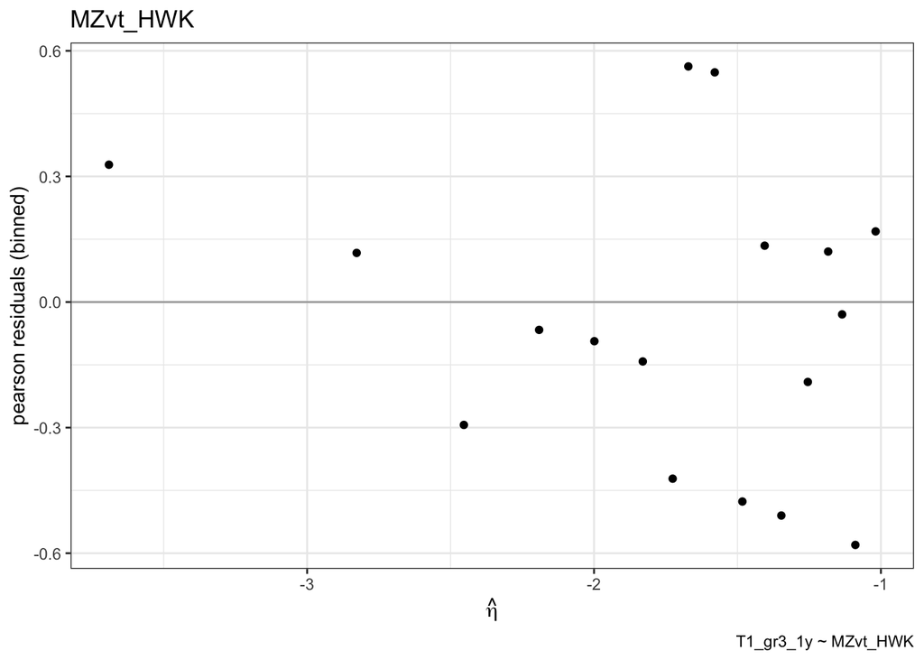

```r
fit <- glm(formula = T1_gr3_1y ~ MZvt_HWK , family = binomial(link = "logit"), data = data_tox)
residual_lp_binned(data_tox, fit = fit, title = "MZvt_HWK")
```

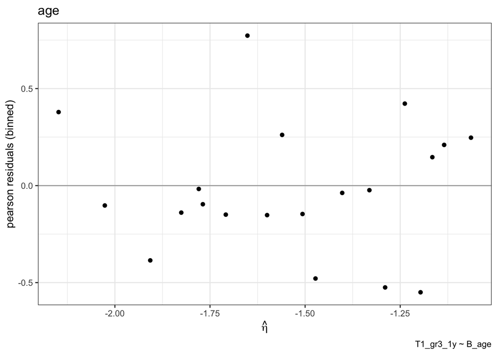

```r
fit <- glm(formula = T1_gr3_1y ~ B_age , family = binomial(link = "logit"), data = data_tox)
residual_lp_binned(data_tox, fit = fit, title = "age")
```

Assess whether residuals are normally distributed.

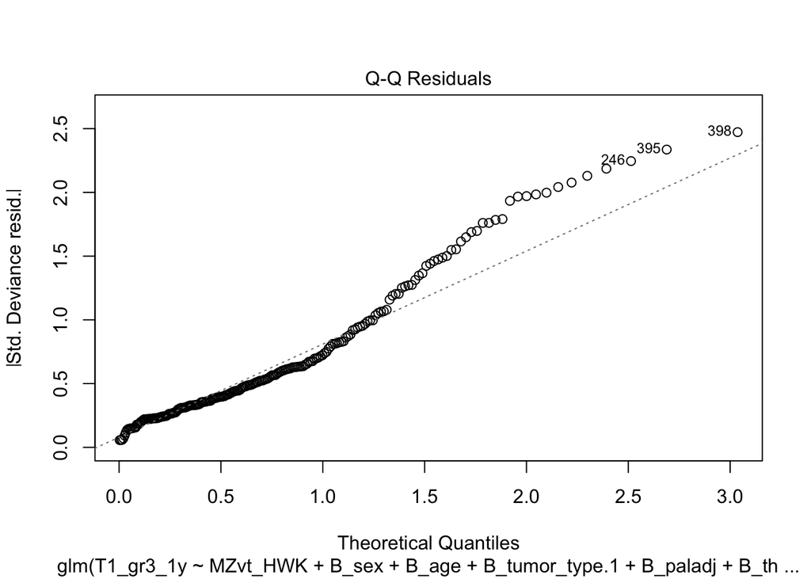

```r
plot(glm_lin.adj, which = 2)
```

Check homoscedasticity.

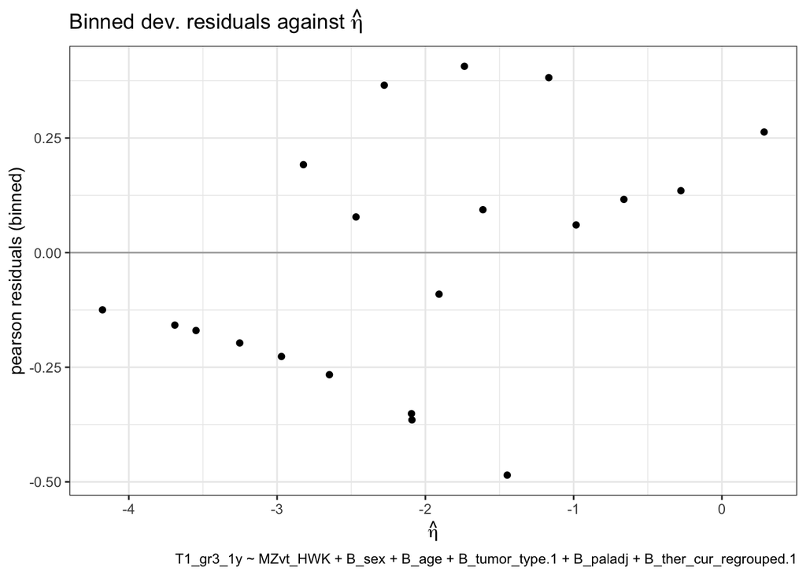

```r
residual_lp_binned(data_tox, glm_lin.adj)
```

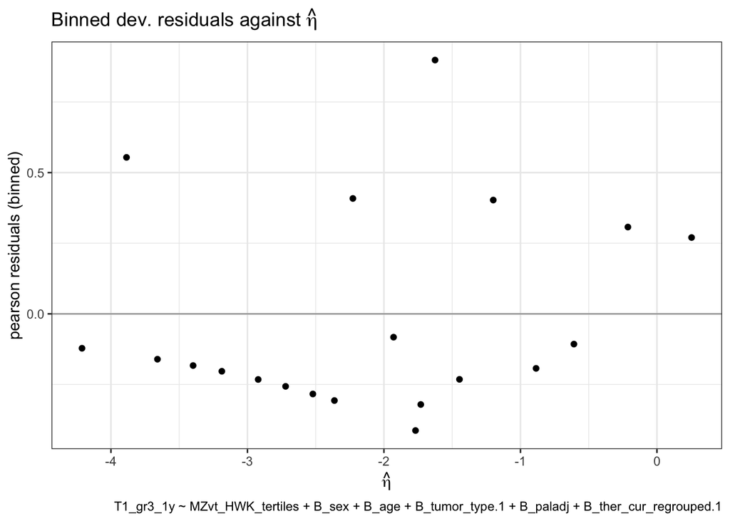

```r
residual_lp_binned(data_tox, glm_tert.adj)
```

### 4.2.4 SirAEs~MVPA-SL logistic regression - continuous splines

#### 4.2.4.1 Knot specification

**We will use the same knots as in the OS analysis.**

We make use of the `rcspline.eval()` function in the `Hmisc` package.

```r
k.pos.MZvt_HWK <- rcspline.eval(data_OS$MZvt_HWK #variable to use splines for
                            , nk=3 #number of knots
                            , inclx=FALSE
                            , knots.only=T #only store knots
                            , type="ordinary"
                            , norm=2
                            , rpm=NULL
                            , pc=FALSE
                            , fractied=0.05)
```

#### 4.2.4.2 Initial regression

Conduct survival analysis using splines regression by the prespecified knots. We make use of the `rcs()` function in package `rms` which provides restricted cubic splines.

```r
glm_rcs.adj <- glm(formula = T1_gr3_1y ~ rms::rcs(MZvt_HWK, k.pos.MZvt_HWK) + B_sex + B_age + B_tumor_type.1 + B_paladj + B_ther_cur_regrouped.1, family = binomial(link = "logit"), data = data_tox)
tbl_regression(glm_rcs.adj, exponentiate=T)
```

| **Characteristic** | **OR**<sup>1</sup> | **95% CI**<sup>1</sup> | **p-value** |
| --- | --- | --- | --- |
| MZvt_HWK |  |  |  |
| rms::rcs(MZvt_HWK, k.pos.MZvt_HWK)MZvt_HWK | 0.80 | 0.63, 1.02 | 0.072 |
| rms::rcs(MZvt_HWK, k.pos.MZvt_HWK)MZvt_HWK' | 1.19 | 0.71, 1.87 | 0.5 |
| B_sex |  |  |  |
| male | — | — |  |
| female | 1.08 | 0.44, 2.59 | 0.9 |
| B_age | 1.06 | 1.02, 1.10 | 0.004 |
| B_tumor_type.1 |  |  |  |
| melanoma | — | — |  |
| NSCLC | 0.57 | 0.08, 2.90 | 0.5 |
| RCC | 0.30 | 0.08, 1.07 | 0.069 |
| other | 0.52 | 0.09, 2.52 | 0.4 |
| B_paladj |  |  |  |
| palliative | — | — |  |
| adjuvant | 0.79 | 0.20, 3.20 | 0.7 |
| B_ther_cur_regrouped.1 |  |  |  |
| anti-PD-(L)1 | — | — |  |
| cICI | 13.4 | 3.41, 63.1 | <0.001 |
| ICI + chemo/targeted therapy | 1.85 | 0.26, 12.7 | 0.5 |

<sup>1</sup> OR = Odds Ratio, CI = Confidence Interval

##### 4.2.4.2.1 Check added value of using splines

We can check whether using restricted cubic splines improves the model fit (statistically). A p-value <0.05 indicates that the model fit is statistically different.

We can check whether `MZvt_HWK` improves the model fit at all (compare a model with splines for `MZvt_HWK` (*Model 1*) to a model without `MZvt_HWK` (*Model 2*)).

```r
anova(glm_rcs.adj,update(glm_rcs.adj,.~.-rms::rcs(MZvt_HWK, k.pos.MZvt_HWK)), test = "Chisq")
```

```
## Analysis of Deviance Table
##
## Model 1: T1_gr3_1y ~ rms::rcs(MZvt_HWK, k.pos.MZvt_HWK) + B_sex + B_age +
##     B_tumor_type.1 + B_paladj + B_ther_cur_regrouped.1
## Model 2: T1_gr3_1y ~ B_sex + B_age + B_tumor_type.1 + B_paladj + B_ther_cur_regrouped.1
##   Resid. Df Resid. Dev Df Deviance Pr(>Chi)
## 1       198     148.99
## 2       200     160.70 -2  -11.708 0.002868 **
## ---
## Signif. codes:  0 '***' 0.001 '**' 0.01 '*' 0.05 '.' 0.1 ' ' 1
```

Than, we check whether using splines for `MZvt_HWK` gives a better fit than adding it as a linear variable (compare a model with splines for `MZvt_HWK` (*Model 1*) to a model with `MZvt_HWK` as is (*Model 2*)).

```r
anova(glm_rcs.adj,update(glm_rcs.adj,.~.-rms::rcs(MZvt_HWK, k.pos.MZvt_HWK)+MZvt_HWK), test = "Chisq")
```

```
## Analysis of Deviance Table
##
## Model 1: T1_gr3_1y ~ rms::rcs(MZvt_HWK, k.pos.MZvt_HWK) + B_sex + B_age +
##     B_tumor_type.1 + B_paladj + B_ther_cur_regrouped.1
## Model 2: T1_gr3_1y ~ B_sex + B_age + B_tumor_type.1 + B_paladj + B_ther_cur_regrouped.1 +
##     MZvt_HWK
##   Resid. Df Resid. Dev Df Deviance Pr(>Chi)
## 1       198     148.99
## 2       199     149.45 -1 -0.46132    0.497
```

#### 4.2.4.3 Visualise the regression coefficient

##### 4.2.4.3.1 Make dummy dataset to obtain predicted OR

```r
if(!is.null(glm_rcs.adj$na.action)){
    newdf <- data_tox[-c(glm_rcs.adj$na.action),]
} else {
  newdf <- data_tox
}

newdf$MZvt_HWK <- c(seq(min(data_tox$MZvt_HWK),max(data_tox$MZvt_HWK),length=(nrow(newdf)-length(k.pos.MZvt_HWK))), k.pos.MZvt_HWK)
```

Now we make a model matrix, which is needed in the subsequent steps.

```r
mm <- model.matrix(glm_rcs.adj, data=newdf)
mm[,!colnames(mm) %in% colnames(mm)[grep("MZvt_HWK",colnames(mm))]] <- 0 # set all variables not about MZvt_HWK to 0
```

For each value of our sequence of `MZvt_HWK`, we obtain its predicted coefficient (=`eta`) and predicted standard error (=`pse`). With these, we compute the predicted 95% conficence intervalls (`plo` and `phi` for lower and upper CI). We store these in a data frame called `est`.

```r
est <- data.frame(MZvt_HWK=newdf$MZvt_HWK,eta=mm%*%coef(glm_rcs.adj)) #predicted coefficient
pvar <- diag(mm %*% tcrossprod(vcov(glm_rcs.adj),mm)) #predicted variance
est <- data.frame(est,pse=sqrt(pvar)) #predicted standard error
est <- with(est,
            data.frame(est,
                       plo=eta-qnorm(0.975)*pse, #predicted lower 95%CI bound
                       phi=eta+qnorm(0.975)*pse)) #predicted upper 95%CI bound
```

For Cox regression and logistic regression we need to exponentiate the coefficient and confidence bounds to obtain OR and 95% CI.

```r
est[,c("eta","plo","phi")] <- exp(est[,c("eta","plo","phi")])
```

We remove duplicates (e.g. if we have two of the same values for `MZvt_HWK`) and sort on `MZvt_HWK`.

```r
est <- est[!duplicated(est),] #remove duplicates
est <- est[order(est$MZvt_HWK),] #sort based on var1 order
```

##### 4.2.4.3.2 Make splines plot

```r
p_splines_tox.OR_MVPASL <- ggplot(data = est
                )+ geom_ribbon(aes(x=MZvt_HWK, ymin = plo, ymax = phi) #color 95%CI
                               , colour = rgb(248,136,44,maxColorValue = 255,alpha=100)
                               , fill=rgb(252,211,178,maxColorValue = 255,alpha=100)
                               , alpha=0.4
                )+ geom_hline(yintercept=1 #add horizontal line at 1
                              , color="dark grey"
                              , linetype="dashed"
                              , size=1
                )+ geom_line(aes(x=MZvt_HWK,y=eta) #add estimated HR
                             , color = "coral3"
                             , size = 1
                )+ geom_point(data=est[est$MZvt_HWK%in%k.pos.MZvt_HWK,] #to plot the places of the knots
                , aes(x=MZvt_HWK, y=eta)
                )+ geom_rug(data = data_tox, aes(x=MZvt_HWK) #add rugs representing real observations for MZvt_HWK
                            , sides = "b"
                            , length = grid::unit(0.02, "npc")
                            , color = "grey"
                            , alpha = .3
                )+ scale_x_continuous(expand = c(0, 0) #set axes directly at 0
                )+ scale_y_log10(breaks = unique(c(0.01,seq(0,1,.2)/10,seq(0,1,.2), seq(0,1,.2)*10))
                )+ coord_cartesian(#xlim = c(0, 201) #set x-axis
                                   ylim = c(0.01,10) #set y-axis
                # )+ ggtitle("" #add title
                )+ xlab("MVPA-SL (hours/week)" #add x-axis label
                )+ ylab("Odds ratio for severe irAE" #add y-axis label
                )+ theme_light( #add/alter theme
                )+ theme(plot.margin = margin(0.5,3,0.5,0.5, unit = "char")
                )

p_splines_tox.OR_MVPASL
```

[output not shown]

### 4.2.5 Visualize predicted probabilities of ficticious patient

Alternatively, we can visualize the predicted probabilities given a patient in whom only the variable of interest changes.

```r
newdf <- with(data_tox,
              expand.grid(MZvt_HWK=c(seq(min(MZvt_HWK),max(MZvt_HWK),length=300), k.pos.MZvt_HWK)
                          , B_sex = levels(B_sex)[1] #reference level for sex
                          , B_age = round(median(B_age), digits = 0)
                          , B_tumor_type.1 = levels(B_tumor_type.1)[1]
                          , B_paladj = levels(B_paladj)[1]
                          , B_ther_cur_regrouped.1 = levels(B_ther_cur_regrouped.1)[1]
                          , B_PS_tri = levels(B_PS_tri)[1]
                          ))
```

```r
newdf$prob <- predict(glm_rcs.adj, newdata = newdf, type = "response")
```

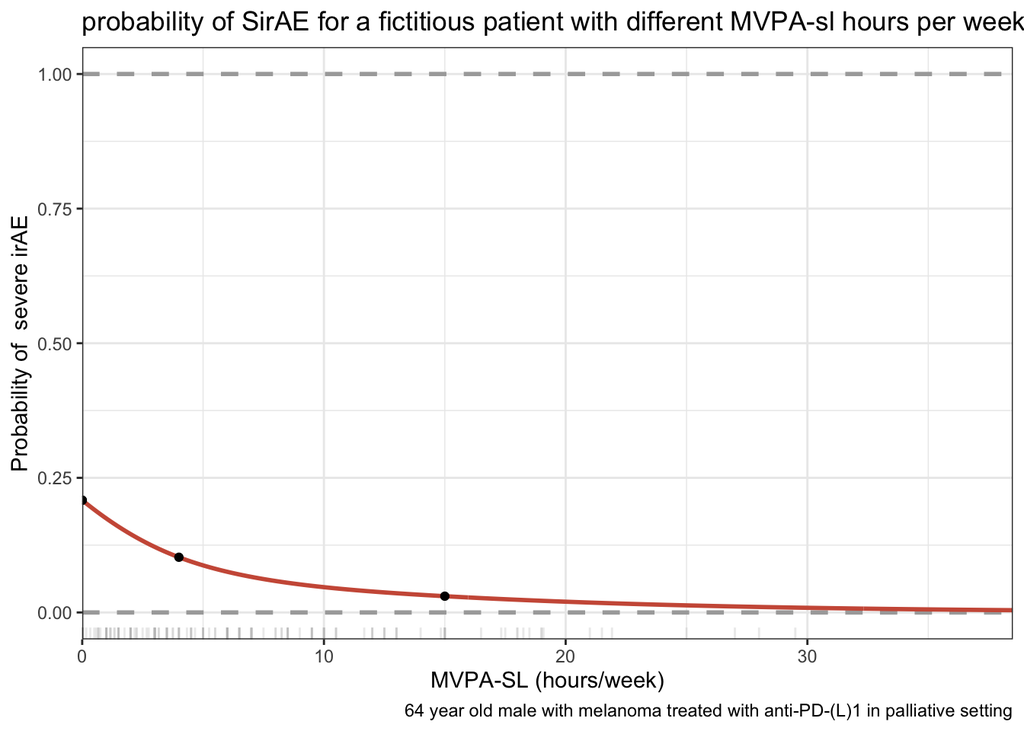

```r
p_splines_tox.prob <- ggplot(data = newdf
                )+ geom_hline(yintercept=1 #add horizontal line at 1
                              , color="dark grey"
                              , linetype="dashed"
                              , size=1
                )+ geom_hline(yintercept=0 #add horizontal line at 0
                              , color="dark grey"
                              , linetype="dashed"
                              , size=1
                )+ geom_line(aes(x=MZvt_HWK,y=prob) #add estimated HR
                             , color = "coral3"
                             , size = 1
                )+ geom_point(data=newdf[newdf$MZvt_HWK%in%k.pos.MZvt_HWK,] #to plot the places of the knots
                , aes(x=MZvt_HWK, y=prob)
                )+ geom_rug(data = data_tox, aes(x=MZvt_HWK) #add rugs representing real observations for MZvt_HWK
                            , sides = "b"
                            , length = grid::unit(0.02, "npc")
                            , color = "grey"
                            , alpha = .3
                )+ scale_x_continuous(expand = c(0, 0) #set axes directly at 0
                )+ coord_cartesian(#xlim = c(0, 201) #set x-axis
                                   ylim = c(0.0,1.0) #set y-axis
                )+ labs(x = "MVPA-SL (hours/week)" #add x-axis label
                        ,y ="Probability of  severe irAE" #add y-axis label
                        ,title = "probability of SirAE for a fictitious patient with different MVPA-sl hours per week"
                        ,caption = "64 year old male with melanoma treated with anti-PD-(L)1 in palliative setting"
                )+ theme_bw( #add/alter theme
                )

p_splines_tox.prob
```

## 4.3 Combine all irAE plots

Make Figure 1.

```r
figure1 <- ggarrange(p_splines_tox.OR_MET, p_splines_tox.OR_MVPASL
                     ,labels = c("A","B")
                     ,ncol=2, nrow=1
                     ,widths = c(1,1), heights = c(1,1)
                     ,common.legend=F
                     )
figure1
```

[output not shown]

Save as PDF.

# 5 Overall survival

We will use Cox proportional hazard regression and make Kaplan Meier curves to assess the correlation of MET-hours (`totmet_hpwk`) and MVPA-SL (`MZvt_HWK`), respectively in three functional forms:

- categorical: tertiles
- (continuous: linear)
- continuous: splines

## 5.1 MET-hours and overall survival

### 5.1.1 OS~MET-hours Kaplan Meier curves - tertiles

Kaplan Meier curve for tertiles (=unadjusted). We first flip the order of levels of `totmet_hpwk_tertiles`, since it appears that patients with highest values have better survival and thus it is more intuitive.

```r
data_OS$totmet_hpwk_tertiles_KM <- factor(data_OS$totmet_hpwk_tertiles
                                          , levels = rev(levels(data_OS$totmet_hpwk_tertiles)))
fit_tert.crude <- survfit(Surv(OS_days, OS_status)~ totmet_hpwk_tertiles_KM , data = data_OS)
KM_OS_MET <- ggsurvplot(fit_tert.crude
                     ,conf.int = F
                     ,pval = F
                     ,xscale="d_m"
                     ,break.x.by=30.4375*6
                     # ,title=""
                     ,xlab="Time (months)"
                     ,ylab="Survival probability"
                     ,legend = c(.28,.28)
                     ,legend.title="MET-hours"
                     ,legend.labs=c(paste0("high ",
                                           levels(data_OS$totmet_hpwk_tertiles_KM)[1]),
                                    paste0("moderate ",
                                           levels(data_OS$totmet_hpwk_tertiles_KM)[2]),
                                    paste0("low ",
                                           levels(data_OS$totmet_hpwk_tertiles_KM)[3]))
                     ,axes.offset=F
                     ,surv.median.line = "none"
                     ,consor=T
                     ,censor.shape=124
                     ,censor.size=2
                     ,risk.table = T
                     ,risk.table.y.text=F
                     ,fontsize=3.5
                     ,ggtheme = theme_survminer(font.x = 12, font.y=12, font.main=12, font.tickslab=10, font.legend=10)
                     ,tables.theme = theme_cleantable(base_size = 10, font.x=10, font.y=10, font.main=12)
          )
KM_OS_MET
```

[output not shown]

We also obtian the survival probability at 12 months with 95% conficence interval.

```r
summary(fit_tert.crude, times = 365.25*12/12)
```

```
## Call: survfit(formula = Surv(OS_days, OS_status) ~ totmet_hpwk_tertiles_KM,
##     data = data_OS)
##
##                 totmet_hpwk_tertiles_KM=(101,371]
##         time       n.risk      n.event     survival      std.err lower 95% CI
##     365.2500      57.0000       9.0000       0.8798       0.0378       0.8087
## upper 95% CI
##       0.9572
##
##                 totmet_hpwk_tertiles_KM=(51,101]
##         time       n.risk      n.event     survival      std.err lower 95% CI
##     365.2500      50.0000      12.0000       0.8286       0.0455       0.7441
## upper 95% CI
##       0.9227
##
##                 totmet_hpwk_tertiles_KM=[0,51]
##         time       n.risk      n.event     survival      std.err lower 95% CI
##     365.2500      46.0000      25.0000       0.6757       0.0538       0.5780
## upper 95% CI
##       0.7900
```

### 5.1.2 OS~MET-hours Cox regression - tertiles

Adjusted Cox regression for tertiles linear variable.

```r
cox_tert.adj <- coxph(Surv(OS_days, OS_status)~ totmet_hpwk_tertiles + B_sex + B_age + B_tumor_type.1 + B_paladj + B_ther_cur_regrouped.1, data = data_OS)
cox_tert.adj_PS <- coxph(Surv(OS_days, OS_status)~ totmet_hpwk_tertiles + B_sex + B_age + B_tumor_type.1 + B_paladj + B_ther_cur_regrouped.1 + B_PS_tri, data = data_OS)
tbl_merge(list(
  tbl_regression(cox_tert.adj, exponentiate=T),
  tbl_regression(cox_tert.adj_PS, exponentiate=T)
  ),
  tab_spanner = c("without ECOG PS", "with ECOG PS")
)
```

| **Characteristic** | without ECOG PS **HR**<sup>1</sup> | without ECOG PS **95% CI**<sup>1</sup> | without ECOG PS **p-value** | with ECOG PS **HR**<sup>1</sup> | with ECOG PS **95% CI**<sup>1</sup> | with ECOG PS **p-value** |
| --- | --- | --- | --- | --- | --- | --- |
| totmet_hpwk_tertiles |  |  |  |  |  |  |
| [0,51] | — | — |  | — | — |  |
| (51,101] | 0.56 | 0.31, 1.02 | 0.056 | 0.68 | 0.36, 1.27 | 0.2 |
| (101,371] | 0.47 | 0.26, 0.86 | 0.015 | 0.57 | 0.31, 1.07 | 0.080 |
| B_sex |  |  |  |  |  |  |
| male | — | — |  | — | — |  |
| female | 1.30 | 0.78, 2.15 | 0.3 | 1.35 | 0.80, 2.26 | 0.3 |
| B_age | 0.99 | 0.97, 1.01 | 0.2 | 0.98 | 0.96, 1.00 | 0.024 |
| B_tumor_type.1 |  |  |  |  |  |  |
| melanoma | — | — |  | — | — |  |
| NSCLC | 1.54 | 0.68, 3.50 | 0.3 | 1.88 | 0.85, 4.16 | 0.12 |
| RCC | 3.79 | 1.41, 10.2 | 0.008 | 3.91 | 1.57, 9.74 | 0.003 |
| other | 1.38 | 0.62, 3.09 | 0.4 | 1.38 | 0.61, 3.11 | 0.4 |
| B_paladj |  |  |  |  |  |  |
| palliative | — | — |  | — | — |  |
| adjuvant | 0.41 | 0.19, 0.88 | 0.023 | 0.60 | 0.27, 1.36 | 0.2 |
| B_ther_cur_regrouped.1 |  |  |  |  |  |  |
| anti-PD-(L)1 | — | — |  | — | — |  |
| cICI | 0.50 | 0.19, 1.36 | 0.2 | 0.69 | 0.28, 1.74 | 0.4 |
| ICI + chemo/targeted therapy | 1.66 | 0.78, 3.50 | 0.2 | 2.16 | 1.03, 4.53 | 0.042 |
| B_PS_tri |  |  |  |  |  |  |
| 0 |  |  |  | — | — |  |
| 1 |  |  |  | 1.58 | 0.87, 2.86 | 0.13 |
| 2-3 |  |  |  | 6.31 | 2.71, 14.7 | <0.001 |

<sup>1</sup> HR = Hazard Ratio, CI = Confidence Interval

### 5.1.3 OS~MET-hours Cox regression - continuous linear

Adjusted Cox regression for continuous linear variable.

```r
cox_lin.crude <- coxph(Surv(OS_days, OS_status)~ totmet_hpwk , data = data_OS)
# summary(cox_lin.crude)
cox_lin.adj <- coxph(Surv(OS_days, OS_status)~ totmet_hpwk + B_sex + B_age + B_tumor_type.1 + B_paladj + B_ther_cur_regrouped.1, data = data_OS)
# tbl_regression(cox_lin.adj, exponentiate=T)
```

### 5.1.4 OS~MET-hours Cox regression - assumptions

Shoenfeld residuals plot: it should be possible to draw a horizontal line between the confidence bands. Otherwise, the Cox proportional hazard assumption is violated, meaning that the baseline hazard is not constant over time.

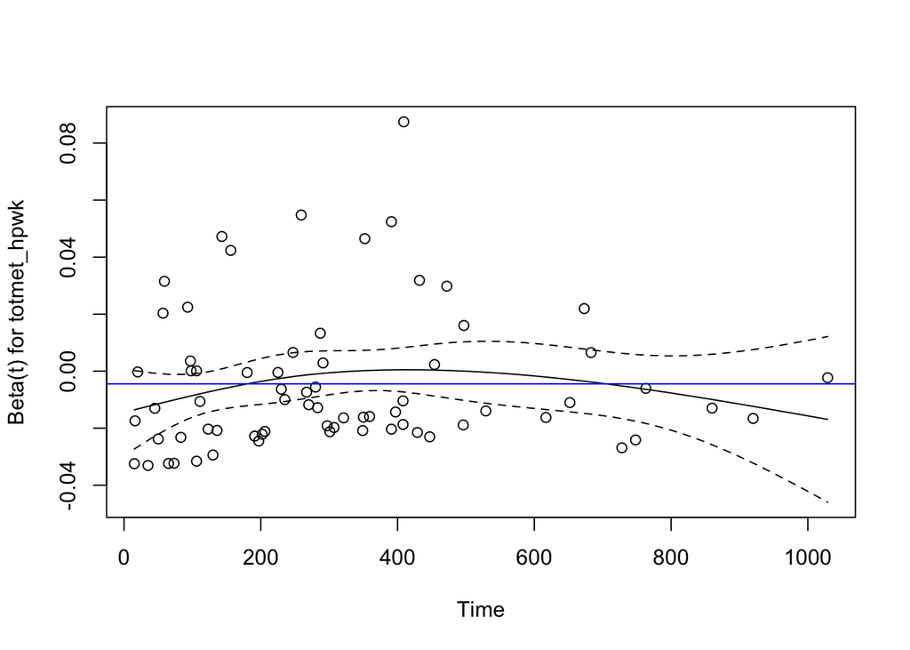

```r
plot(cox.zph(cox_lin.adj, transform = "identity")[1])
abline(h=cox_lin.adj$coefficients[1], col="blue")
```

Martingale residuals can help decide upon the functional form of a dependent variable: This should give a more or less straight line. If not, consider a transformation of the dependent variable.

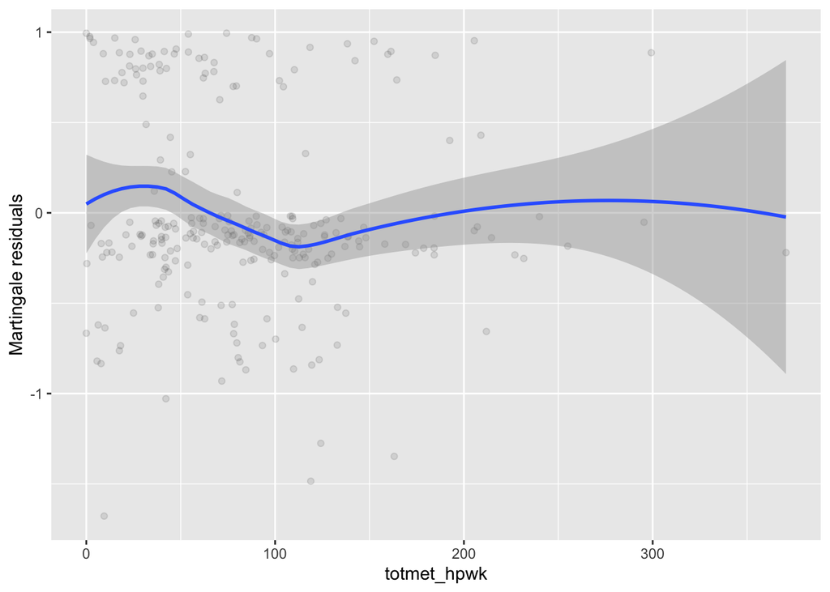

```r
fit0 <- update(cox_lin.adj,~.- totmet_hpwk)
resid_X <- resid(fit0, type = "martingale")
if(is.null(fit0$na.action)){
  df.tmp <- data.frame(X=data_OS$totmet_hpwk, resid_X=resid_X)
} else {
  df.tmp <- data.frame(X=data_OS[-c(fit0$na.action),]$totmet_hpwk, resid_X=resid_X)
}
ggplot(data = df.tmp
       )+ geom_point(aes(x=X, y=resid_X), color="black", alpha=0.1
       )+ geom_smooth(aes(x=X, y=resid_X), method = loess
       )+ labs(x="totmet_hpwk", y="Martingale residuals")
```

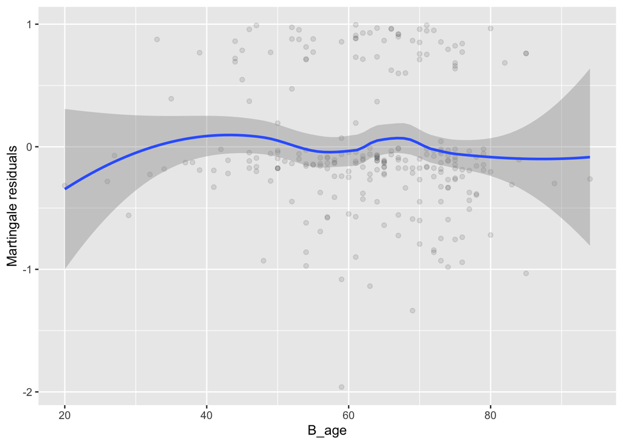

```r
fit0 <- update(cox_lin.adj,~.- B_age)
resid_X <- resid(fit0, type = "martingale")
if(is.null(fit0$na.action)){
  df.tmp <- data.frame(X=data_OS$B_age, resid_X=resid_X)
} else {
  df.tmp <- data.frame(X=data_OS[-c(fit0$na.action),]$B_age, resid_X=resid_X)
}
ggplot(data = df.tmp
       )+ geom_point(aes(x=X, y=resid_X), color="black", alpha=0.1
       )+ geom_smooth(aes(x=X, y=resid_X), method = loess
       )+ labs(x="B_age", y="Martingale residuals")
```

```r
rm(fit0, resid_X, df.tmp)
```

### 5.1.5 OS~MET-hours Cox regression - splines

#### 5.1.5.1 Knot specification

We make use of the `rcspline.eval()` function in the `Hmisc` package.

```r
k.pos.totmet_hpwk <- rcspline.eval(data_OS$totmet_hpwk #variable to use splines for
                            , nk=3 #number of knots
                            , inclx=FALSE
                            , knots.only=T #only store knots
                            , type="ordinary"
                            , norm=2
                            , rpm=NULL
                            , pc=FALSE
                            , fractied=0.05)
```

#### 5.1.5.2 Initial regression

Conduct survival analysis using splines regression by the prespecified knots. We make use of the `rcs()` function in package `rms` which provides restricted cubic splines.

```r
cox_rcs.adj <- coxph(Surv(OS_days, OS_status)~ rms::rcs(totmet_hpwk, k.pos.totmet_hpwk) + B_sex + B_age + B_tumor_type.1 + B_paladj + B_ther_cur_regrouped.1, data = data_OS)
tbl_regression(cox_rcs.adj, exponentiate=T)
```

| **Characteristic** | **HR**<sup>1</sup> | **95% CI**<sup>1</sup> | **p-value** |
| --- | --- | --- | --- |
| totmet_hpwk |  |  |  |
| rms::rcs(totmet_hpwk, k.pos.totmet_hpwk)totmet_hpwk | 0.99 | 0.98, 1.00 | 0.006 |
| rms::rcs(totmet_hpwk, k.pos.totmet_hpwk)totmet_hpwk' | 1.02 | 1.00, 1.03 | 0.023 |
| B_sex |  |  |  |
| male | — | — |  |
| female | 1.30 | 0.78, 2.15 | 0.3 |
| B_age | 0.99 | 0.97, 1.01 | 0.2 |
| B_tumor_type.1 |  |  |  |
| melanoma | — | — |  |
| NSCLC | 1.49 | 0.66, 3.36 | 0.3 |
| RCC | 3.41 | 1.27, 9.13 | 0.015 |
| other | 1.30 | 0.57, 2.95 | 0.5 |
| B_paladj |  |  |  |
| palliative | — | — |  |
| adjuvant | 0.40 | 0.18, 0.87 | 0.020 |
| B_ther_cur_regrouped.1 |  |  |  |
| anti-PD-(L)1 | — | — |  |
| cICI | 0.50 | 0.18, 1.34 | 0.2 |
| ICI + chemo/targeted therapy | 1.71 | 0.82, 3.55 | 0.2 |

<sup>1</sup> HR = Hazard Ratio, CI = Confidence Interval

##### 5.1.5.2.1 Check added value of using splines

We can check whether using restricted cubic splines improves the model fit (statistically). A p-value <0.05 indicates that the model fit is statistically different.

We can check whether `totmet_hpwk` improves the model fit at all (compare a model with splines for `totmet_hpwk` (*Model 1*) to a model without `totmet_hpwk` (*Model 2*)).

```r
anova(cox_rcs.adj,update(cox_rcs.adj,.~.-rms::rcs(totmet_hpwk, k.pos.totmet_hpwk)))
```

```
## Analysis of Deviance Table
##  Cox model: response is  Surv(OS_days, OS_status)
##  Model 1: ~ rms::rcs(totmet_hpwk, k.pos.totmet_hpwk) + B_sex + B_age + B_tumor_type.1 + B_paladj + B_ther_cur_regrouped.1
##  Model 2: ~ B_sex + B_age + B_tumor_type.1 + B_paladj + B_ther_cur_regrouped.1
##    loglik  Chisq Df Pr(>|Chi|)
## 1 -328.73
## 2 -332.65 7.8509  2    0.01973 *
## ---
## Signif. codes:  0 '***' 0.001 '**' 0.01 '*' 0.05 '.' 0.1 ' ' 1
```

Then, we check whether using splines for `totmet_hpwk` gives a better fit than adding it as a linear variable (compare a model with splines for `totmet_hpwk` (*Model 1*) to a model with `totmet_hpwk` as is (*Model 2*)).

```r
anova(cox_rcs.adj,update(cox_rcs.adj,.~totmet_hpwk+.-rms::rcs(totmet_hpwk, k.pos.totmet_hpwk)))
```

```
## Analysis of Deviance Table
##  Cox model: response is  Surv(OS_days, OS_status)
##  Model 1: ~ rms::rcs(totmet_hpwk, k.pos.totmet_hpwk) + B_sex + B_age + B_tumor_type.1 + B_paladj + B_ther_cur_regrouped.1
##  Model 2: ~ totmet_hpwk + B_sex + B_age + B_tumor_type.1 + B_paladj + B_ther_cur_regrouped.1
##    loglik  Chisq Df Pr(>|Chi|)
## 1 -328.73
## 2 -330.99 4.5363  1    0.03318 *
## ---
## Signif. codes:  0 '***' 0.001 '**' 0.01 '*' 0.05 '.' 0.1 ' ' 1
```

#### 5.1.5.3 Visualise the regression coefficient

We want to visualise the hazard rate (HR) for death (in case of overall survival (OS)) over the trajectory of our variable of interest (`totmet_hpwk`). To do this, we will mak a dummy dataset to predict the HR for certain values of `totmet_hpwk`. We will also obtain the 95% confidence interval (CI).

##### 5.1.5.3.1 Make dummy dataset to obtain predicted HR

```r
newdf <- with(data_OS,
              expand.grid(totmet_hpwk=c(seq(min(totmet_hpwk),max(totmet_hpwk),length=300), k.pos.totmet_hpwk)
                          , B_sex = levels(B_sex)[1] #reference level for sex
                          , B_age = 0 #reference age for age (note, you could also use e.g. median, this wouldn't change the results)
                          , B_tumor_type.1 = levels(B_tumor_type.1)[1]
                          , B_paladj = levels(B_paladj)[1]
                          , B_ther_cur_regrouped.1 = levels(B_ther_cur_regrouped.1)[1]
                          , B_PS_tri = levels(B_PS_tri)[1]
                          ))
```

Now we make a model matrix, which is needed in the subsequent steps.

```r
mm <- model.matrix(cox_rcs.adj,data=newdf)
mm[,!colnames(mm) %in% colnames(mm)[grep("totmet_hpwk",colnames(mm))]] <- 0 # set all variables not about totmet_hpwk to 0
```

For each value of our sequence of `totmet_hpwk`, we obtain its predicted coefficient (=`eta`) and predicted standard error (=`pse`). With these, we compute the predicted 95% conficence intervalls (`plo` and `phi` for lower and upper CI). We store these in a data frame called `est`.

```r
est <- data.frame(totmet_hpwk=newdf$totmet_hpwk,eta=mm%*%coef(cox_rcs.adj)) #predicted coefficient
pvar <- diag(mm %*% tcrossprod(vcov(cox_rcs.adj),mm)) #predicted variance
est <- data.frame(est,pse=sqrt(pvar)) #predicted standard error
est <- with(est,
            data.frame(est,
                       plo=eta-qnorm(0.975)*pse, #predicted lower 95%CI bound
                       phi=eta+qnorm(0.975)*pse)) #predicted upper 95%CI bound
```

For Cox regression and logistic regression we need to exponentiate the coefficient and confidence bounds to obtain HR and 95% CI.

```r
est[,c("eta","plo","phi")] <- exp(est[,c("eta","plo","phi")])
```

We remove duplicates (e.g. if we have two of the same values for `totmet_hpwk`) and sort on `totmet_hpwk`.

```r
est <- est[!duplicated(est),] #remove duplicates
est <- est[order(est$totmet_hpwk),] #sort based on var1 order
```

##### 5.1.5.3.2 Make splines plot

```r
p_splines_OS_MET <- ggplot(data = est
                )+ geom_ribbon(aes(x=totmet_hpwk, ymin = plo, ymax = phi) #color 95%CI
                               , colour = rgb(248,136,44,maxColorValue = 255,alpha=100)
                               , fill=rgb(252,211,178,maxColorValue = 255,alpha=100)
                               , alpha=0.4
                )+ geom_hline(yintercept=1 #add horizontal line at 1
                              , color="dark grey"
                              , linetype="dashed"
                              , linewidth=1
                )+ geom_line(aes(x=totmet_hpwk,y=eta) #add estimated HR
                             , color = "coral3"
                             , linewidth= 1
                )+ geom_point(data=est[est$totmet_hpwk%in%k.pos.totmet_hpwk,] #to plot the places of the knots
                              , aes(x=totmet_hpwk, y=eta)
                )+ geom_rug(data = data_OS, aes(x=totmet_hpwk) #add rugs representing real observations for totmet_hpwk
                            , sides = "b"
                            , length = grid::unit(0.02, "npc")
                            , color = "grey"
                            , alpha = .3
                )+ scale_x_continuous(expand = c(0, 0) #set axes directly at 0
                )+ scale_y_log10(breaks = unique(c(0.1,seq(0,1,.2), seq(0,1,.2)*10))
                # )+ annotation_logticks(base = 10, sides = "l", outside=F , scaled = T, color = "black",alpha = .5
                )+ coord_cartesian(#xlim = c(0, 201) #set x-axis
                                   ylim = c(0.1,10) #set y-axis
                # )+ ggtitle("" #add title
                )+ xlab("MET-hours (/week)" #add x-axis label
                )+ ylab("Hazard ratio for death" #add y-axis label
                )+ theme_light( #add/alter theme
                )+ theme(plot.margin = margin(0.5,3,0.5,0.5, unit = "char")
                )

p_splines_OS_MET
```

[output not shown]

## 5.2 MVPA-SL and overall survival

### 5.2.1 OS~MVPA-SL Kaplan Meier curves - tertiles

Kaplan Meier curve for tertiles (=unadjusted).

```r
fit_tert.crude <- survfit(Surv(OS_days, OS_status)~ MZvt_HWK_tertiles , data = data_OS)
ggsurvplot(fit_tert.crude)
```

[output not shown]

```r
data_OS$MZvt_HWK_tertiles_KM <- factor(data_OS$MZvt_HWK_tertiles
                                          , levels = rev(levels(data_OS$MZvt_HWK_tertiles)))
fit_tert.crude <- survfit(Surv(OS_days, OS_status)~ MZvt_HWK_tertiles_KM , data = data_OS)
KM_OS_MVPASL <- ggsurvplot(fit_tert.crude
                     ,conf.int = F
                     ,pval = F
                     ,xscale="d_m"
                     ,break.x.by=30.4375*6
                     # ,title=""
                     ,xlab="Time (months)"
                     ,ylab="Survival probability"
                     ,legend = c(.28,.28)
                     ,legend.title="MVPA-SL"
                     ,legend.labs=c(paste0("high ",
                                           levels(data_OS$MZvt_HWK_tertiles_KM)[1]),
                                    paste0("moderate ",
                                           levels(data_OS$MZvt_HWK_tertiles_KM)[2]),
                                    paste0("low ",
                                           levels(data_OS$MZvt_HWK_tertiles_KM)[3]))
                     ,axes.offset=F
                     ,surv.median.line = "none"
                     ,consor=T
                     ,censor.shape=124
                     ,censor.size=2
                     ,risk.table = T
                     ,risk.table.y.text=F
                     ,fontsize=3.5
                     ,ggtheme = theme_survminer(font.x = 12, font.y=12, font.main=12, font.tickslab=10, font.legend=10)
                     ,tables.theme = theme_cleantable(base_size = 10, font.x=10, font.y=10, font.main=12)
          )
KM_OS_MVPASL
```

[output not shown]

We also obtian the survival probability at 12 months with 95% conficence interval.

```r
summary(fit_tert.crude, times = 365.25*12/12)
```

```
## Call: survfit(formula = Surv(OS_days, OS_status) ~ MZvt_HWK_tertiles_KM,
##     data = data_OS)
##
##                 MZvt_HWK_tertiles_KM=(6.5,38.5]
##         time       n.risk      n.event     survival      std.err lower 95% CI
##     365.2500      54.0000       8.0000       0.8856       0.0382       0.8138
## upper 95% CI
##       0.9638
##
##                 MZvt_HWK_tertiles_KM=(1.5,6.5]
##         time       n.risk      n.event     survival      std.err lower 95% CI
##     365.2500      54.0000      14.0000       0.8140       0.0452       0.7301
## upper 95% CI
##       0.9077
##
##                 MZvt_HWK_tertiles_KM=[0,1.5]
##         time       n.risk      n.event     survival      std.err lower 95% CI
##     365.2500      45.0000      24.0000       0.6944       0.0526       0.5986
## upper 95% CI
##       0.8056
```

### 5.2.2 OS~MVPA-SL Cox regression - tertiles

Adjusted Cox regression for tertiles linear variable.

```r
cox_tert.adj <- coxph(Surv(OS_days, OS_status)~ MZvt_HWK_tertiles + B_sex + B_age + B_tumor_type.1 + B_paladj + B_ther_cur_regrouped.1, data = data_OS)
cox_tert.adj_PS <- coxph(Surv(OS_days, OS_status)~ MZvt_HWK_tertiles + B_sex + B_age + B_tumor_type.1 + B_paladj + B_ther_cur_regrouped.1 + B_PS_tri, data = data_OS)
tbl_merge(list(
  tbl_regression(cox_tert.adj, exponentiate=T),
  tbl_regression(cox_tert.adj_PS, exponentiate=T)
  ),
  tab_spanner = c("without ECOG PS", "with ECOG PS")
)
```

| **Characteristic** | without ECOG PS **HR**<sup>1</sup> | without ECOG PS **95% CI**<sup>1</sup> | without ECOG PS **p-value** | with ECOG PS **HR**<sup>1</sup> | with ECOG PS **95% CI**<sup>1</sup> | with ECOG PS **p-value** |
| --- | --- | --- | --- | --- | --- | --- |
| MZvt_HWK_tertiles |  |  |  |  |  |  |
| [0,1.5] | — | — |  | — | — |  |
| (1.5,6.5] | 0.69 | 0.40, 1.20 | 0.2 | 0.79 | 0.45, 1.39 | 0.4 |
| (6.5,38.5] | 0.57 | 0.30, 1.09 | 0.091 | 0.70 | 0.36, 1.36 | 0.3 |
| B_sex |  |  |  |  |  |  |
| male | — | — |  | — | — |  |
| female | 1.16 | 0.70, 1.94 | 0.6 | 1.26 | 0.75, 2.12 | 0.4 |
| B_age | 0.99 | 0.97, 1.01 | 0.4 | 0.98 | 0.96, 1.00 | 0.061 |
| B_tumor_type.1 |  |  |  |  |  |  |
| melanoma | — | — |  | — | — |  |
| NSCLC | 1.48 | 0.63, 3.48 | 0.4 | 1.86 | 0.83, 4.17 | 0.13 |
| RCC | 3.50 | 1.29, 9.48 | 0.014 | 3.78 | 1.51, 9.44 | 0.004 |
| other | 1.46 | 0.64, 3.33 | 0.4 | 1.46 | 0.64, 3.31 | 0.4 |
| B_paladj |  |  |  |  |  |  |
| palliative | — | — |  | — | — |  |
| adjuvant | 0.42 | 0.19, 0.92 | 0.031 | 0.65 | 0.28, 1.48 | 0.3 |
| B_ther_cur_regrouped.1 |  |  |  |  |  |  |
| anti-PD-(L)1 | — | — |  | — | — |  |
| cICI | 0.51 | 0.19, 1.41 | 0.2 | 0.70 | 0.28, 1.77 | 0.4 |
| ICI + chemo/targeted therapy | 1.74 | 0.82, 3.70 | 0.15 | 2.30 | 1.10, 4.81 | 0.026 |
| B_PS_tri |  |  |  |  |  |  |
| 0 |  |  |  | — | — |  |
| 1 |  |  |  | 1.66 | 0.93, 2.99 | 0.088 |
| 2-3 |  |  |  | 6.97 | 3.01, 16.1 | <0.001 |

<sup>1</sup> HR = Hazard Ratio, CI = Confidence Interval

### 5.2.3 OS~MVPA-SL Cox regression - continuous linear

Adjusted Cox regression for continuous linear variable.

```r
cox_lin.crude <- coxph(Surv(OS_days, OS_status)~ MZvt_HWK , data = data_OS)
# summary(cox_lin.crude)
cox_lin.adj <- coxph(Surv(OS_days, OS_status)~ MZvt_HWK + B_sex + B_age + B_tumor_type.1 + B_paladj + B_ther_cur_regrouped.1, data = data_OS)
# tbl_regression(cox_lin.adj, exponentiate=T)
```

### 5.2.4 OS~MVPA-SL Cox regression - assumptions

Shoenfeld residuals plot: it should be possible to draw a horizontal line between the confidence bands. Otherwise, the Cox proportional hazard assumption is violated, meaning that the baseline hazard is not constant over time.

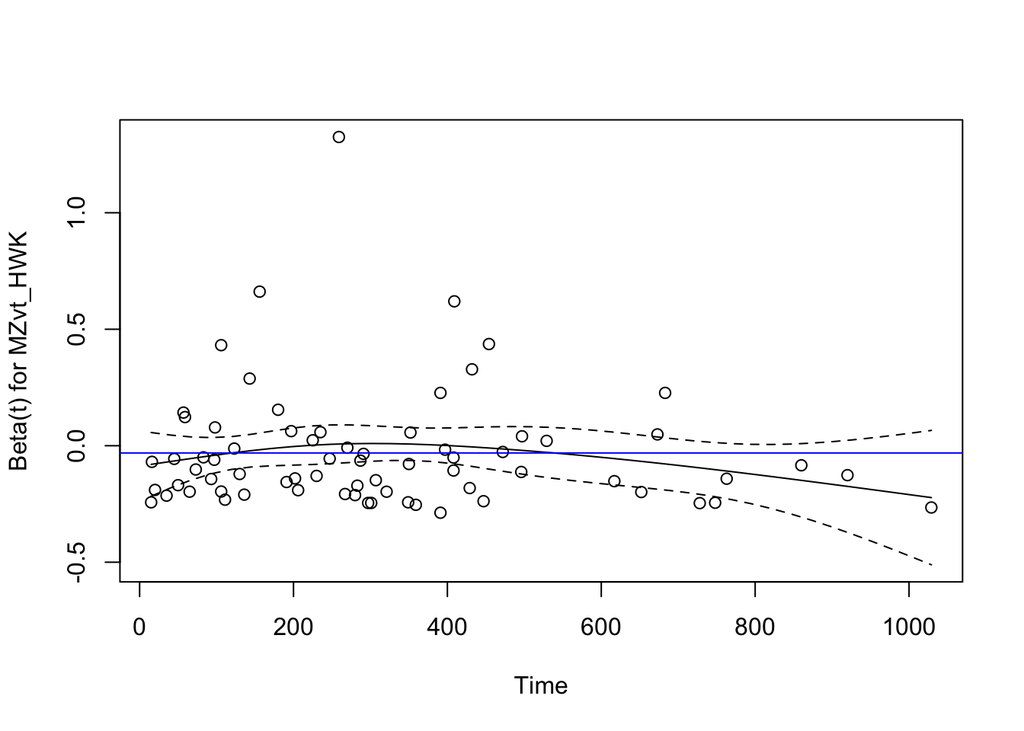

```r
plot(cox.zph(cox_lin.adj, transform = "identity")[1])
abline(h=cox_lin.adj$coefficients[1], col="blue")
```

Martingale residuals can help decide upon the functional form of a dependent variable: This should give a more or less straight line. If not, consider a transformation of the dependent variable.

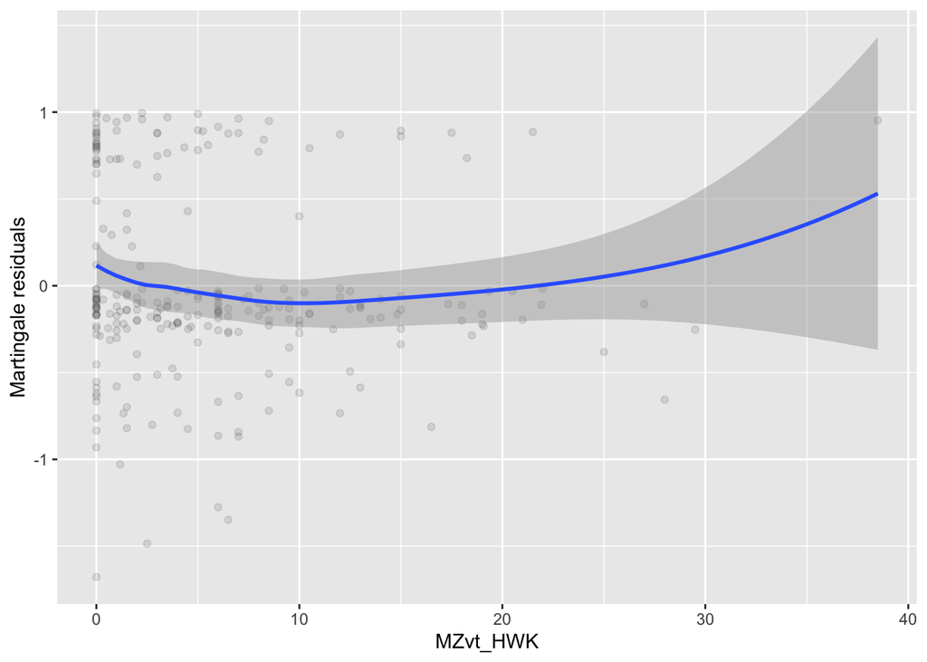

```r
fit0 <- update(cox_lin.adj,~.- MZvt_HWK)
resid_X <- resid(fit0, type = "martingale")
if(is.null(fit0$na.action)){
  df.tmp <- data.frame(X=data_OS$MZvt_HWK, resid_X=resid_X)
} else {
  df.tmp <- data.frame(X=data_OS[-c(fit0$na.action),]$MZvt_HWK, resid_X=resid_X)
}
ggplot(data = df.tmp
       )+ geom_point(aes(x=X, y=resid_X), color="black", alpha=0.1
       )+ geom_smooth(aes(x=X, y=resid_X), method = loess
       )+ labs(x="MZvt_HWK", y="Martingale residuals")
```

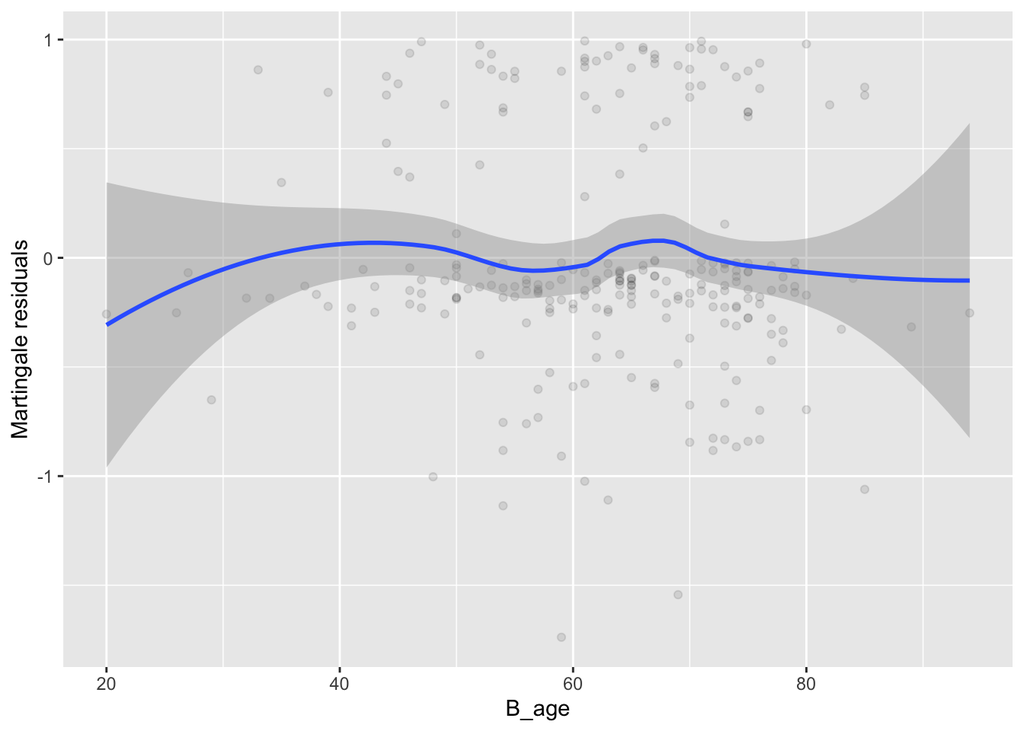

```r
fit0 <- update(cox_lin.adj,~.- B_age)
resid_X <- resid(fit0, type = "martingale")
if(is.null(fit0$na.action)){
  df.tmp <- data.frame(X=data_OS$B_age, resid_X=resid_X)
} else {
  df.tmp <- data.frame(X=data_OS[-c(fit0$na.action),]$B_age, resid_X=resid_X)
}
ggplot(data = df.tmp
       )+ geom_point(aes(x=X, y=resid_X), color="black", alpha=0.1
       )+ geom_smooth(aes(x=X, y=resid_X), method = loess
       )+ labs(x="B_age", y="Martingale residuals")
```

```r
rm(fit0, resid_X, df.tmp)
```

### 5.2.5 OS~MVPA-SL Cox regression - splines

#### 5.2.5.1 Knot specification

We make use of the `rcspline.eval()` function in the `Hmisc` package.

```r
k.pos.MZvt_HWK <- rcspline.eval(data_OS$MZvt_HWK #variable to use splines for
                            , nk=3 #number of knots
                            , inclx=FALSE
                            , knots.only=T #only store knots
                            , type="ordinary"
                            , norm=2
                            , rpm=NULL
                            , pc=FALSE
                            , fractied=0.05)
```

#### 5.2.5.2 Initial regression

Conduct survival analysis using splines regression by the prespecified knots. We make use of the `rcs()` function in package `rms` which provides restricted cubic splines.

```r
cox_rcs.adj <- coxph(Surv(OS_days, OS_status)~ rms::rcs(MZvt_HWK, k.pos.MZvt_HWK) + B_sex + B_age + B_tumor_type.1 + B_paladj + B_ther_cur_regrouped.1, data = data_OS)
tbl_regression(cox_rcs.adj, exponentiate=T)
```

| **Characteristic** | **HR**<sup>1</sup> | **95% CI**<sup>1</sup> | **p-value** |
| --- | --- | --- | --- |
| MZvt_HWK |  |  |  |
| rms::rcs(MZvt_HWK, k.pos.MZvt_HWK)MZvt_HWK | 0.85 | 0.75, 0.97 | 0.018 |
| rms::rcs(MZvt_HWK, k.pos.MZvt_HWK)MZvt_HWK' | 1.28 | 1.02, 1.61 | 0.035 |
| B_sex |  |  |  |
| male | — | — |  |
| female | 1.14 | 0.69, 1.91 | 0.6 |
| B_age | 0.99 | 0.97, 1.01 | 0.3 |
| B_tumor_type.1 |  |  |  |
| melanoma | — | — |  |
| NSCLC | 1.52 | 0.64, 3.57 | 0.3 |
| RCC | 3.41 | 1.26, 9.25 | 0.016 |
| other | 1.42 | 0.63, 3.22 | 0.4 |
| B_paladj |  |  |  |
| palliative | — | — |  |
| adjuvant | 0.40 | 0.18, 0.89 | 0.025 |
| B_ther_cur_regrouped.1 |  |  |  |
| anti-PD-(L)1 | — | — |  |
| cICI | 0.50 | 0.18, 1.36 | 0.2 |
| ICI + chemo/targeted therapy | 1.67 | 0.79, 3.55 | 0.2 |

<sup>1</sup> HR = Hazard Ratio, CI = Confidence Interval

##### 5.2.5.2.1 Check added value of using splines

We can check whether using restricted cubic splines improves the model fit (statistically). A p-value <0.05 indicates that the model fit is statistically different.

We can check whether `MZvt_HWK` improves the model fit at all (compare a model with splines for `MZvt_HWK` (*Model 1*) to a model without `MZvt_HWK` (*Model 2*)).

```r
anova(cox_rcs.adj,update(cox_rcs.adj,.~.-rms::rcs(MZvt_HWK, k.pos.MZvt_HWK)))
```

```
## Analysis of Deviance Table
##  Cox model: response is  Surv(OS_days, OS_status)
##  Model 1: ~ rms::rcs(MZvt_HWK, k.pos.MZvt_HWK) + B_sex + B_age + B_tumor_type.1 + B_paladj + B_ther_cur_regrouped.1
##  Model 2: ~ B_sex + B_age + B_tumor_type.1 + B_paladj + B_ther_cur_regrouped.1
##    loglik  Chisq Df Pr(>|Chi|)
## 1 -329.66
## 2 -332.65 5.9773  2    0.05036 .
## ---
## Signif. codes:  0 '***' 0.001 '**' 0.01 '*' 0.05 '.' 0.1 ' ' 1
```

Than, we check whether using splines for `MZvt_HWK` gives a better fit than adding it as a linear variable (compare a model with splines for `MZvt_HWK` (*Model 1*) to a model with `MZvt_HWK` as is (*Model 2*)).

```r
anova(cox_rcs.adj,update(cox_rcs.adj,.~.-rms::rcs(MZvt_HWK, k.pos.MZvt_HWK)+MZvt_HWK))
```

```
## Analysis of Deviance Table
##  Cox model: response is  Surv(OS_days, OS_status)
##  Model 1: ~ rms::rcs(MZvt_HWK, k.pos.MZvt_HWK) + B_sex + B_age + B_tumor_type.1 + B_paladj + B_ther_cur_regrouped.1
##  Model 2: ~ B_sex + B_age + B_tumor_type.1 + B_paladj + B_ther_cur_regrouped.1 + MZvt_HWK
##    loglik  Chisq Df Pr(>|Chi|)
## 1 -329.66
## 2 -331.79 4.2448  1    0.03937 *
## ---
## Signif. codes:  0 '***' 0.001 '**' 0.01 '*' 0.05 '.' 0.1 ' ' 1
```

#### 5.2.5.3 Visualise the regression coefficient

We want to visualise the hazard rate (HR) for death (in case of overall survival (OS)) over the trajectory of our variable of interest (`MZvt_HWK`). To do this, we will mak a dummy dataset to predict the HR for certain values of `MZvt_HWK`. We will also obtain the 95% confidence interval (CI).

##### 5.2.5.3.1 Make dummy dataset to obtain predicted HR

```r
newdf <- with(data_OS,
              expand.grid(MZvt_HWK=c(seq(min(MZvt_HWK),max(MZvt_HWK),length=300), k.pos.MZvt_HWK)
                          , B_sex = levels(B_sex)[1] #reference level for sex
                          , B_age = 0 #reference age for age (note, you could also use e.g. median, this wouldn't change the results)
                          , B_tumor_type.1 = levels(B_tumor_type.1)[1]
                          , B_paladj = levels(B_paladj)[1]
                          , B_ther_cur_regrouped.1 = levels(B_ther_cur_regrouped.1)[1]
                          , B_PS_tri = levels(B_PS_tri)[1]
                          ))
```

Now we make a model matrix, which is needed in the subsequent steps.

```r
mm <- model.matrix(cox_rcs.adj,data=newdf)
mm[,!colnames(mm) %in% colnames(mm)[grep("MZvt_HWK",colnames(mm))]] <- 0 # set all variables not about MZvt_HWK to 0
```

For each value of our sequence of `MZvt_HWK`, we obtain its predicted coefficient (=`eta`) and predicted standard error (=`pse`). With these, we compute the predicted 95% conficence intervalls (`plo` and `phi` for lower and upper CI). We store these in a data frame called `est`.

```r
est <- data.frame(MZvt_HWK=newdf$MZvt_HWK,eta=mm%*%coef(cox_rcs.adj)) #predicted coefficient
pvar <- diag(mm %*% tcrossprod(vcov(cox_rcs.adj),mm)) #predicted variance
est <- data.frame(est,pse=sqrt(pvar)) #predicted standard error
est <- with(est,
            data.frame(est,
                       plo=eta-qnorm(0.975)*pse, #predicted lower 95%CI bound
                       phi=eta+qnorm(0.975)*pse)) #predicted upper 95%CI bound
```

For Cox regression and logistic regression we need to exponentiate the coefficient and confidence bounds to obtain HR and 95% CI.

```r
est[,c("eta","plo","phi")] <- exp(est[,c("eta","plo","phi")])
```

We remove duplicates (e.g. if we have two of the same values for `MZvt_HWK`) and sort on `MZvt_HWK`.

```r
est <- est[!duplicated(est),] #remove duplicates
est <- est[order(est$MZvt_HWK),] #sort based on var1 order
```

##### 5.2.5.3.2 Make splines plot

```r
p_splines_OS_MVPASL <- ggplot(data = est
                )+ geom_ribbon(aes(x=MZvt_HWK, ymin = plo, ymax = phi) #color 95%CI
                               , colour = rgb(248,136,44,maxColorValue = 255,alpha=100)
                               , fill=rgb(252,211,178,maxColorValue = 255,alpha=100)
                               , alpha=0.4
                )+ geom_hline(yintercept=1 #add horizontal line at 1
                              , color="dark grey"
                              , linetype="dashed"
                              , size=1
                )+ geom_line(aes(x=MZvt_HWK,y=eta) #add estimated HR
                             , color = "coral3"
                             , size = 1
                )+ geom_point(data=est[est$MZvt_HWK%in%k.pos.MZvt_HWK,] #to plot the places of the knots
                              , aes(x=MZvt_HWK, y=eta)
                )+ geom_rug(data = data_OS, aes(x=MZvt_HWK) #add rugs representing real observations for MZvt_HWK
                            , sides = "b"
                            , length = grid::unit(0.02, "npc")
                            , color = "grey"
                            , alpha = .5
                )+ scale_x_continuous(expand = c(0,0) #set axes directly at 0
                )+ scale_y_log10(breaks = unique(c(0.1,seq(0,1,.2), seq(0,1,.2)*10))
                # )+ annotation_logticks(base = 10, sides = "l", outside=F , scaled = T, color = "black",alpha = .5
                )+ coord_cartesian(#xlim = c(0, 30) #set x-axis
                            ylim = c(0.1,10) #set y-axis
                # )+ ggtitle("" #add title
                )+ xlab("MVPA-SL (hours/week)" #add x-axis label
                )+ ylab("Hazard ratio for death" #add y-axis label
                )+ theme_light( #add/alter theme
                )+ theme(plot.margin = margin(0.5,3,0.5,0.5, unit = "char")
                )

p_splines_OS_MVPASL
```

[output not shown]

## 5.3 Combine all OS plots

Make Figure 2.

```r
KM_OS_MET <- ggarrange(KM_OS_MET$plot,KM_OS_MET$table
                       , ncol=1, nrow=2
                       , heights= c(.75,.25))
KM_OS_MVPASL <- ggarrange(KM_OS_MVPASL$plot,KM_OS_MVPASL$table
                       , ncol=1, nrow=2
                       , heights= c(.75,.25))

figure2 <- ggarrange(KM_OS_MET, p_splines_OS_MET,
                     KM_OS_MVPASL, p_splines_OS_MVPASL
                     ,labels = c("A","B","C","D")
                     ,ncol=2, nrow=2
                     ,widths = c(1,1), heights = c(1,1)
                     ,common.legend=F
                     )
figure2
```

[output not shown]

Save as PDF.